# **Louisiana Health Insurance: An Analysis of Medicaid Expansion**

```python
health15.dtypes
```

```
Label                  object
Ascension Total        object
Ascension Insured      object
Ascension Insured %    object
Ascension Uninsured    object
                        ...
US Total               object
US Insured             object
US Insured %           object
US Uninsured           object
US Uninsured %         object
Length: 91, dtype: object
```

Lastly, we transpose the dataset in order for the observations to be seen as columns.

```python
health21.set_index("Label",inplace=True)
health21 = health21.transpose()
```

```python
health21
```

| Label | Civilian noninstitutionalized population | Age: <6 | Age: 6-17 | Age: 18-24 | Age: 25-34 | Age: 35-44 | Age: 45-54 | Age: 55-64 | Age: 65-74 | Age: 75+ | ... | $25,000 to $49,999 | $50,000 to $74,999 | $75,000 to $99,999 | $100,000 and over | Pop where poverty status determined | < 138% of poverty threshold | 138 to 399 percent of the poverty threshold | >= 400% of poverty threshold | Below 100 percent of the poverty threshold | Population 18 to 64 years |
| --- | --- | --- | --- | --- | --- | --- | --- | --- | --- | --- | --- | --- | --- | --- | --- | --- | --- | --- | --- | --- | --- |
| Ascension Total | 127,526 | 11,433 | 23,717 | 9,614 | 16,625 | 19,484 | 14,970 | 14,655 | 10,671 | 6,357 | ... | 24,560 | 19,968 | 19,047 | 53,767 | 127,341 | 22,612 | 50,030 | 54,699 | 15,268 | NaN |
| Ascension Insured | 118,592 | 10,915 | 22,919 | 8,961 | 14,029 | 17,851 | 13,658 | 13,231 | 10,671 | 6,357 | ... | 21,467 | 18,278 | 17,432 | 51,436 | 118,407 | 20,598 | 44,468 | 53,341 | 13,254 | NaN |
| Ascension Insured % | 93.0% | 95.5% | 96.6% | 93.2% | 84.4% | 91.6% | 91.2% | 90.3% | 100.0% | 100.0% | ... | 87.4% | 91.5% | 91.5% | 95.7% | 93.0% | 91.1% | 88.9% | 97.5% | 86.8% | NaN |
| Ascension Uninsured | 8,934 | 518 | 798 | 653 | 2,596 | 1,633 | 1,312 | 1,424 | 0 | 0 | ... | 3,093 | 1,690 | 1,615 | 2,331 | 8,934 | 2,014 | 5,562 | 1,358 | 2,014 | NaN |
| Ascension Uninsured % | 7.0% | 4.5% | 3.4% | 6.8% | 15.6% | 8.4% | 8.8% | 9.7% | 0.0% | 0.0% | ... | 12.6% | 8.5% | 8.5% | 4.3% | 7.0% | 8.9% | 11.1% | 2.5% | 13.2% | NaN |
| ... | ... | ... | ... | ... | ... | ... | ... | ... | ... | ... | ... | ... | ... | ... | ... | ... | ... | ... | ... | ... | ... |
| US Total | 326,912,547 | 22,579,171 | 55,251,332 | 29,194,212 | 39,736,024 | 42,801,119 | 40,177,707 | 42,431,040 | 33,423,349 | 21,318,593 | ... | 52,636,739 | 52,420,604 | 44,130,048 | 134,415,894 | 323,173,982 | 59,917,950 | 127,403,787 | 135,852,245 | 41,362,026 | NaN |
| US Insured | 298,685,665 | 21,565,200 | 52,100,615 | 25,059,158 | 33,724,063 | 37,236,650 | 35,779,068 | 38,923,950 | 33,087,867 | 21,209,094 | ... | 45,822,787 | 46,669,851 | 40,369,230 | 127,910,378 | 295,171,921 | 50,962,094 | 113,526,496 | 130,683,331 | 35,025,846 | NaN |
| US Insured % | 91.4% | 95.5% | 94.3% | 85.8% | 84.9% | 87.0% | 89.1% | 91.7% | 99.0% | 99.5% | ... | 87.1% | 89.0% | 91.5% | 95.2% | 91.3% | 85.1% | 89.1% | 96.2% | 84.7% | NaN |
| US Uninsured | 28,226,882 | 1,013,971 | 3,150,717 | 4,135,054 | 6,011,961 | 5,564,469 | 4,398,639 | 3,507,090 | 335,482 | 109,499 | ... | 6,813,952 | 5,750,753 | 3,760,818 | 6,505,516 | 28,002,061 | 8,955,856 | 13,877,291 | 5,168,914 | 6,336,180 | NaN |
| US Uninsured % | 8.6% | 4.5% | 5.7% | 14.2% | 15.1% | 13.0% | 10.9% | 8.3% | 1.0% | 0.5% | ... | 12.9% | 11.0% | 8.5% | 4.8% | 8.7% | 14.9% | 10.9% | 3.8% | 15.3% | NaN |

90 rows × 57 columns

```python
health15.set_index("Label",inplace=True)
health15 = health15.transpose()
```

```python
health15
```

| Label | Civilian noninstitutionalized population | Age: <6 | Age: 6-17 | Age: 18-24 | Age: 25-34 | Age: 35-44 | Age: 45-54 | Age: 55-64 | Age: 65-74 | Age: 75+ | ... | Under $25,000 | $25,000 to $49,999 | $50,000 to $74,999 | $75,000 to $99,999 | $100,000 and over | Pop where poverty status determined | < 138% of poverty threshold | 138 to 199 percent of the poverty threshold | 200 to 399 percent of the poverty threshold | >= 400% of poverty threshold |
| --- | --- | --- | --- | --- | --- | --- | --- | --- | --- | --- | --- | --- | --- | --- | --- | --- | --- | --- | --- | --- | --- |
| Ascension Total | 118,671 | 10,276 | 22,631 | 10,193 | 17,116 | 17,484 | 15,404 | 13,455 | 7,735 | 4,377 | ... | 13,045 | 18,731 | 15,854 | 17,155 | 53,797 | 118,671 | 16,267 | 10,934 | 33,430 | 58,040 |
| Ascension Insured | 110,276 | 10,219 | 22,527 | 8,600 | 14,959 | 15,806 | 13,880 | 12,178 | 7,730 | 4,377 | ... | 10,760 | 16,100 | 14,430 | 15,772 | 53,143 | 110,276 | 13,047 | 9,296 | 30,567 | 57,366 |
| Ascension Insured % | 92.9% | 99.4% | 99.5% | 84.4% | 87.4% | 90.4% | 90.1% | 90.5% | 99.9% | 100.0% | ... | 82.5% | 86.0% | 91.0% | 91.9% | 98.8% | 92.9% | 80.2% | 85.0% | 91.4% | 98.8% |
| Ascension Uninsured | 8,395 | 57 | 104 | 1,593 | 2,157 | 1,678 | 1,524 | 1,277 | 5 | 0 | ... | 2,285 | 2,631 | 1,424 | 1,383 | 654 | 8,395 | 3,220 | 1,638 | 2,863 | 674 |
| Ascension Uninsured % | 7.1% | 0.6% | 0.5% | 15.6% | 12.6% | 9.6% | 9.9% | 9.5% | 0.1% | 0.0% | ... | 17.5% | 14.0% | 9.0% | 8.1% | 1.2% | 7.1% | 19.8% | 15.0% | 8.6% | 1.2% |
| ... | ... | ... | ... | ... | ... | ... | ... | ... | ... | ... | ... | ... | ... | ... | ... | ... | ... | ... | ... | ... | ... |
| US Total | 316,450,569 | 23,746,599 | 49,745,332 | 30,571,816 | 42,769,883 | 40,032,167 | 42,609,478 | 40,538,272 | 27,289,273 | 19,147,749 | ... | 51,281,973 | 66,138,622 | 57,325,411 | 43,043,638 | 94,862,617 | 312,780,720 | 68,091,759 | 35,237,726 | 93,261,064 | 116,190,171 |
| US Insured | 286,693,025 | 22,795,315 | 47,162,631 | 25,990,137 | 35,290,681 | 34,214,331 | 37,863,314 | 37,331,595 | 27,009,619 | 19,035,402 | ... | 43,630,639 | 57,066,212 | 51,533,624 | 39,976,592 | 91,003,092 | 283,223,843 | 56,399,632 | 29,999,621 | 84,506,859 | 112,317,731 |
| US Insured % | 90.6% | 96.0% | 94.8% | 85.0% | 82.5% | 85.5% | 88.9% | 92.1% | 99.0% | 99.4% | ... | 85.1% | 86.3% | 89.9% | 92.9% | 95.9% | 90.6% | 82.8% | 85.1% | 90.6% | 96.7% |
| US Uninsured | 29,757,544 | 951,284 | 2,582,701 | 4,581,679 | 7,479,202 | 5,817,836 | 4,746,164 | 3,206,677 | 279,654 | 112,347 | ... | 7,651,334 | 9,072,410 | 5,791,787 | 3,067,046 | 3,859,525 | 29,556,877 | 11,692,127 | 5,238,105 | 8,754,205 | 3,872,440 |
| US Uninsured % | 9.4% | 4.0% | 5.2% | 15.0% | 17.5% | 14.5% | 11.1% | 7.9% | 1.0% | 0.6% | ... | 14.9% | 13.7% | 10.1% | 7.1% | 4.1% | 9.4% | 17.2% | 14.9% | 9.4% | 3.3% |

90 rows × 58 columns

### A quick note on Unicode Characters

There is an interesting error that we get when we try to access the column "Male". This is because there are indentations (more specifically non breaking spaces) in the original dataset that have been handled automatically by PANDAS replacing them with the "\xa0". Lets look at an example

```python
health21["\xa0\xa0\xa0\xa0\xa0\xa0\xa0\xa0Male"]
```

```
Ascension Total               61,710
Ascension Insured             57,329
Ascension Insured %            92.9%
Ascension Uninsured            4,381
Ascension Uninsured %           7.1%
                            ...
US Total                 160,634,821
US Insured               145,030,492
US Insured %                   90.3%
US Uninsured              15,604,329
US Uninsured %                  9.7%
Name:         Male, Length: 90, dtype: object
```

If we had tried health_insur_LA_Tp["(spacespacespace)Male"], PANDAS would have thrown a KeyError. To us, non-breaking spaces look like regular spaces but as we can see above they are handled internally much differently. To avoid having to type "\ax0" a bunch of times, we are going to rename the columns to exclude these non-breaking spaces.

Thanks to aechase on GitHub and FolksTalk.com for helping to elucidate exactly what was going on here

Links: https://www.folkstalk.com/tech/pandas-xa0-with-code-examples/, https://github.com/pandas-dev/pandas/issues/14579

Now that the data has been roughly cleaned and organized, it is important to check that the datatypes of the variables are numbers so operations can be performed on them.

```python
health21.columns = health21.columns.str.replace('\xa0', '')
health15.columns = health15.columns.str.replace('\xa0', '')
```

### Typing the Data

```python
health21.dtypes
```

```
Label
Civilian noninstitutionalized population              object
Age: <6                                               object
Age: 6-17                                             object
Age: 18-24                                            object
Age: 25-34                                            object
Age: 35-44                                            object
Age: 45-54                                            object
Age: 55-64                                            object
Age: 65-74                                            object
Age: 75+                                              object
Male                                                  object
Female                                                object
White alone                                           object
Black or African American alone                       object
American Indian and Alaska Native alone               object
Asian alone                                           object
Native Hawaiian and Other Pacific Islander alone      object
Some other race alone                                 object
Two or more races                                     object
Hispanic or Latino (of any race)                      object
White alone, not Hispanic or Latino                   object
In family households                                  object
In married couple families                            object
In other families                                     object
Male reference, no spouse                             object
Female reference, no spouse                           object
Non-family household/Other                            object
Native born                                           object
Foreign born                                          object
Naturalized                                           object
Not a citizen                                         object
With a disability                                     object
No disability                                         object
Population 26 years and over                          object
Less than high school graduate                        object
High school grad                                      object
Some college or associate's degree                    object
Bachelor's degree or higher                           object
In labor force                                        object
Employed                                              object
Unemployed                                            object
Not in labor force                                    object
Worked full-time, year round in the past 12 months    object
Worked < full-time in past 12 months                  object
Did not work                                          object
Total household population                            object
Under $25,000                                         object
$25,000 to $49,999                                    object
$50,000 to $74,999                                    object
$75,000 to $99,999                                    object
$100,000 and over                                     object
Pop where poverty status determined                   object
< 138% of poverty threshold                           object
138 to 399 percent of the poverty threshold           object
>= 400% of poverty threshold                          object
Below 100 percent of the poverty threshold            object
Population 18 to 64 years                             object
dtype: object
```

```python
health21.dtypes
```

```
Label
Civilian noninstitutionalized population              object
Age: <6                                               object
Age: 6-17                                             object
Age: 18-24                                            object
Age: 25-34                                            object
Age: 35-44                                            object
Age: 45-54                                            object
Age: 55-64                                            object
Age: 65-74                                            object
Age: 75+                                              object
Male                                                  object
Female                                                object
White alone                                           object
Black or African American alone                       object
American Indian and Alaska Native alone               object
Asian alone                                           object
Native Hawaiian and Other Pacific Islander alone      object
Some other race alone                                 object
Two or more races                                     object
Hispanic or Latino (of any race)                      object
White alone, not Hispanic or Latino                   object
In family households                                  object
In married couple families                            object
In other families                                     object
Male reference, no spouse                             object
Female reference, no spouse                           object
Non-family household/Other                            object
Native born                                           object
Foreign born                                          object
Naturalized                                           object
Not a citizen                                         object
With a disability                                     object
No disability                                         object
Population 26 years and over                          object
Less than high school graduate                        object
High school grad                                      object
Some college or associate's degree                    object
Bachelor's degree or higher                           object
In labor force                                        object
Employed                                              object
Unemployed                                            object
Not in labor force                                    object
Worked full-time, year round in the past 12 months    object
Worked < full-time in past 12 months                  object
Did not work                                          object
Total household population                            object
Under $25,000                                         object
$25,000 to $49,999                                    object
$50,000 to $74,999                                    object
$75,000 to $99,999                                    object
$100,000 and over                                     object
Pop where poverty status determined                   object
< 138% of poverty threshold                           object
138 to 399 percent of the poverty threshold           object
>= 400% of poverty threshold                          object
Below 100 percent of the poverty threshold            object
Population 18 to 64 years                             object
dtype: object
```

Looks like they aren't numbers, rather they are strings. Lets cast them as numbers on both datasets so we can perform meaningful operations on them. However, we have to get rid of the other string characters (such as percentage signs and commas) before we can do this.

```python
health21.replace(regex = ",", value = "", inplace = True)
health21.replace(regex = "%", value = "", inplace = True)
health21.replace(regex = "N", value = "", inplace = True)
health21=health21.apply(pd.to_numeric, errors = "coerce")

health21
```

| Label | Civilian noninstitutionalized population | Age: <6 | Age: 6-17 | Age: 18-24 | Age: 25-34 | Age: 35-44 | Age: 45-54 | Age: 55-64 | Age: 65-74 | Age: 75+ | ... | $25,000 to $49,999 | $50,000 to $74,999 | $75,000 to $99,999 | $100,000 and over | Pop where poverty status determined | < 138% of poverty threshold | 138 to 399 percent of the poverty threshold | >= 400% of poverty threshold | Below 100 percent of the poverty threshold | Population 18 to 64 years |
| --- | --- | --- | --- | --- | --- | --- | --- | --- | --- | --- | --- | --- | --- | --- | --- | --- | --- | --- | --- | --- | --- |
| Ascension Total | 127526.0 | 11433.0 | 23717.0 | 9614.0 | 16625.0 | 19484.0 | 14970.0 | 14655.0 | 10671.0 | 6357.0 | ... | 24560.0 | 19968.0 | 19047.0 | 53767.0 | 127341.0 | 22612.0 | 50030.0 | 54699.0 | 15268.0 | NaN |
| Ascension Insured | 118592.0 | 10915.0 | 22919.0 | 8961.0 | 14029.0 | 17851.0 | 13658.0 | 13231.0 | 10671.0 | 6357.0 | ... | 21467.0 | 18278.0 | 17432.0 | 51436.0 | 118407.0 | 20598.0 | 44468.0 | 53341.0 | 13254.0 | NaN |
| Ascension Insured % | 93.0 | 95.5 | 96.6 | 93.2 | 84.4 | 91.6 | 91.2 | 90.3 | 100.0 | 100.0 | ... | 87.4 | 91.5 | 91.5 | 95.7 | 93.0 | 91.1 | 88.9 | 97.5 | 86.8 | NaN |
| Ascension Uninsured | 8934.0 | 518.0 | 798.0 | 653.0 | 2596.0 | 1633.0 | 1312.0 | 1424.0 | 0.0 | 0.0 | ... | 3093.0 | 1690.0 | 1615.0 | 2331.0 | 8934.0 | 2014.0 | 5562.0 | 1358.0 | 2014.0 | NaN |
| Ascension Uninsured % | 7.0 | 4.5 | 3.4 | 6.8 | 15.6 | 8.4 | 8.8 | 9.7 | 0.0 | 0.0 | ... | 12.6 | 8.5 | 8.5 | 4.3 | 7.0 | 8.9 | 11.1 | 2.5 | 13.2 | NaN |
| ... | ... | ... | ... | ... | ... | ... | ... | ... | ... | ... | ... | ... | ... | ... | ... | ... | ... | ... | ... | ... | ... |
| US Total | 326912547.0 | 22579171.0 | 55251332.0 | 29194212.0 | 39736024.0 | 42801119.0 | 40177707.0 | 42431040.0 | 33423349.0 | 21318593.0 | ... | 52636739.0 | 52420604.0 | 44130048.0 | 134415894.0 | 323173982.0 | 59917950.0 | 127403787.0 | 135852245.0 | 41362026.0 | NaN |
| US Insured | 298685665.0 | 21565200.0 | 52100615.0 | 25059158.0 | 33724063.0 | 37236650.0 | 35779068.0 | 38923950.0 | 33087867.0 | 21209094.0 | ... | 45822787.0 | 46669851.0 | 40369230.0 | 127910378.0 | 295171921.0 | 50962094.0 | 113526496.0 | 130683331.0 | 35025846.0 | NaN |
| US Insured % | 91.4 | 95.5 | 94.3 | 85.8 | 84.9 | 87.0 | 89.1 | 91.7 | 99.0 | 99.5 | ... | 87.1 | 89.0 | 91.5 | 95.2 | 91.3 | 85.1 | 89.1 | 96.2 | 84.7 | NaN |
| US Uninsured | 28226882.0 | 1013971.0 | 3150717.0 | 4135054.0 | 6011961.0 | 5564469.0 | 4398639.0 | 3507090.0 | 335482.0 | 109499.0 | ... | 6813952.0 | 5750753.0 | 3760818.0 | 6505516.0 | 28002061.0 | 8955856.0 | 13877291.0 | 5168914.0 | 6336180.0 | NaN |
| US Uninsured % | 8.6 | 4.5 | 5.7 | 14.2 | 15.1 | 13.0 | 10.9 | 8.3 | 1.0 | 0.5 | ... | 12.9 | 11.0 | 8.5 | 4.8 | 8.7 | 14.9 | 10.9 | 3.8 | 15.3 | NaN |

90 rows × 57 columns

```python
health15.replace(regex = ",", value = "", inplace = True)
health15.replace(regex = "%", value = "", inplace = True)
health15.replace(regex = "N", value = "", inplace = True)
health15=health15.apply(pd.to_numeric, errors = "coerce")

health15
```

| Label | Civilian noninstitutionalized population | Age: <6 | Age: 6-17 | Age: 18-24 | Age: 25-34 | Age: 35-44 | Age: 45-54 | Age: 55-64 | Age: 65-74 | Age: 75+ | ... | Under $25,000 | $25,000 to $49,999 | $50,000 to $74,999 | $75,000 to $99,999 | $100,000 and over | Pop where poverty status determined | < 138% of poverty threshold | 138 to 199 percent of the poverty threshold | 200 to 399 percent of the poverty threshold | >= 400% of poverty threshold |
| --- | --- | --- | --- | --- | --- | --- | --- | --- | --- | --- | --- | --- | --- | --- | --- | --- | --- | --- | --- | --- | --- |
| Ascension Total | 118671.0 | 10276.0 | 22631.0 | 10193.0 | 17116.0 | 17484.0 | 15404.0 | 13455.0 | 7735.0 | 4377.0 | ... | 13045.0 | 18731.0 | 15854.0 | 17155.0 | 53797.0 | 118671.0 | 16267.0 | 10934.0 | 33430.0 | 58040.0 |
| Ascension Insured | 110276.0 | 10219.0 | 22527.0 | 8600.0 | 14959.0 | 15806.0 | 13880.0 | 12178.0 | 7730.0 | 4377.0 | ... | 10760.0 | 16100.0 | 14430.0 | 15772.0 | 53143.0 | 110276.0 | 13047.0 | 9296.0 | 30567.0 | 57366.0 |
| Ascension Insured % | 92.9 | 99.4 | 99.5 | 84.4 | 87.4 | 90.4 | 90.1 | 90.5 | 99.9 | 100.0 | ... | 82.5 | 86.0 | 91.0 | 91.9 | 98.8 | 92.9 | 80.2 | 85.0 | 91.4 | 98.8 |
| Ascension Uninsured | 8395.0 | 57.0 | 104.0 | 1593.0 | 2157.0 | 1678.0 | 1524.0 | 1277.0 | 5.0 | 0.0 | ... | 2285.0 | 2631.0 | 1424.0 | 1383.0 | 654.0 | 8395.0 | 3220.0 | 1638.0 | 2863.0 | 674.0 |
| Ascension Uninsured % | 7.1 | 0.6 | 0.5 | 15.6 | 12.6 | 9.6 | 9.9 | 9.5 | 0.1 | 0.0 | ... | 17.5 | 14.0 | 9.0 | 8.1 | 1.2 | 7.1 | 19.8 | 15.0 | 8.6 | 1.2 |
| ... | ... | ... | ... | ... | ... | ... | ... | ... | ... | ... | ... | ... | ... | ... | ... | ... | ... | ... | ... | ... | ... |
| US Total | 316450569.0 | 23746599.0 | 49745332.0 | 30571816.0 | 42769883.0 | 40032167.0 | 42609478.0 | 40538272.0 | 27289273.0 | 19147749.0 | ... | 51281973.0 | 66138622.0 | 57325411.0 | 43043638.0 | 94862617.0 | 312780720.0 | 68091759.0 | 35237726.0 | 93261064.0 | 116190171.0 |
| US Insured | 286693025.0 | 22795315.0 | 47162631.0 | 25990137.0 | 35290681.0 | 34214331.0 | 37863314.0 | 37331595.0 | 27009619.0 | 19035402.0 | ... | 43630639.0 | 57066212.0 | 51533624.0 | 39976592.0 | 91003092.0 | 283223843.0 | 56399632.0 | 29999621.0 | 84506859.0 | 112317731.0 |
| US Insured % | 90.6 | 96.0 | 94.8 | 85.0 | 82.5 | 85.5 | 88.9 | 92.1 | 99.0 | 99.4 | ... | 85.1 | 86.3 | 89.9 | 92.9 | 95.9 | 90.6 | 82.8 | 85.1 | 90.6 | 96.7 |
| US Uninsured | 29757544.0 | 951284.0 | 2582701.0 | 4581679.0 | 7479202.0 | 5817836.0 | 4746164.0 | 3206677.0 | 279654.0 | 112347.0 | ... | 7651334.0 | 9072410.0 | 5791787.0 | 3067046.0 | 3859525.0 | 29556877.0 | 11692127.0 | 5238105.0 | 8754205.0 | 3872440.0 |
| US Uninsured % | 9.4 | 4.0 | 5.2 | 15.0 | 17.5 | 14.5 | 11.1 | 7.9 | 1.0 | 0.6 | ... | 14.9 | 13.7 | 10.1 | 7.1 | 4.1 | 9.4 | 17.2 | 14.9 | 9.4 | 3.3 |

90 rows × 58 columns

Now we have cleaned the dataset of all string characters and converted the data to numbers, casting all the missing values as a NaN

### Split Each Dataframe

At this point, it seems like we would be able to start doing some analysis. However, there are repeat observations (parishes) on the table, but in different units. Essentially, there are three different tables smushed into one. To make our analysis meaningful, we will have to filter the larger tables into smaller ones with the same units.

#### health21_percent

```python
#isolating the percentages
health21_percent = pd.DataFrame(health21[health21.index.str.contains("%")])
health21_percent.rename(columns={"Civilian noninstitutionalized population": "Percent"}, inplace=True)
health21_percent
```

| Label | Percent | Age: <6 | Age: 6-17 | Age: 18-24 | Age: 25-34 | Age: 35-44 | Age: 45-54 | Age: 55-64 | Age: 65-74 | Age: 75+ | ... | $25,000 to $49,999 | $50,000 to $74,999 | $75,000 to $99,999 | $100,000 and over | Pop where poverty status determined | < 138% of poverty threshold | 138 to 399 percent of the poverty threshold | >= 400% of poverty threshold | Below 100 percent of the poverty threshold | Population 18 to 64 years |
| --- | --- | --- | --- | --- | --- | --- | --- | --- | --- | --- | --- | --- | --- | --- | --- | --- | --- | --- | --- | --- | --- |
| Ascension Insured % | 93.0 | 95.5 | 96.6 | 93.2 | 84.4 | 91.6 | 91.2 | 90.3 | 100.0 | 100.0 | ... | 87.4 | 91.5 | 91.5 | 95.7 | 93.0 | 91.1 | 88.9 | 97.5 | 86.8 | NaN |
| Ascension Uninsured % | 7.0 | 4.5 | 3.4 | 6.8 | 15.6 | 8.4 | 8.8 | 9.7 | 0.0 | 0.0 | ... | 12.6 | 8.5 | 8.5 | 4.3 | 7.0 | 8.9 | 11.1 | 2.5 | 13.2 | NaN |
| Bossier Insured % | 90.6 | 99.0 | 95.6 | 80.1 | 78.1 | 87.6 | 89.6 | 88.2 | 100.0 | 100.0 | ... | 86.8 | 92.5 | 96.7 | 93.3 | 90.6 | 84.2 | 89.9 | 95.3 | 80.9 | NaN |
| Bossier Uninsured % | 9.4 | 1.0 | 4.4 | 19.9 | 21.9 | 12.4 | 10.4 | 11.8 | 0.0 | 0.0 | ... | 13.2 | 7.5 | 3.3 | 6.7 | 9.4 | 15.8 | 10.1 | 4.7 | 19.1 | NaN |
| Caddo Insured % | 93.8 | 99.3 | 98.6 | 88.4 | 86.4 | 91.0 | 89.2 | 92.3 | 100.0 | 100.0 | ... | 92.9 | 90.7 | 96.0 | 94.9 | 93.8 | 93.6 | 93.3 | 94.8 | 94.4 | NaN |
| Caddo Uninsured % | 6.2 | 0.7 | 1.4 | 11.6 | 13.6 | 9.0 | 10.8 | 7.7 | 0.0 | 0.0 | ... | 7.1 | 9.3 | 4.0 | 5.1 | 6.2 | 6.4 | 6.7 | 5.2 | 5.6 | NaN |
| Calcasieu Insured % | 92.0 | 96.3 | 96.4 | 89.9 | 79.7 | 91.2 | 85.9 | 95.0 | 98.5 | 98.8 | ... | 87.5 | 92.3 | 88.2 | 97.9 | 91.9 | 90.1 | 89.5 | 95.4 | 88.9 | NaN |
| Calcasieu Uninsured % | 8.0 | 3.7 | 3.6 | 10.1 | 20.3 | 8.8 | 14.1 | 5.0 | 1.5 | 1.2 | ... | 12.5 | 7.7 | 11.8 | 2.1 | 8.1 | 9.9 | 10.5 | 4.6 | 11.1 | NaN |
| East Baton Rouge Insured % | 92.4 | 95.8 | 97.6 | 89.4 | 85.3 | 87.1 | 90.6 | 92.9 | 98.8 | 99.1 | ... | 89.9 | 93.2 | 94.3 | 95.8 | 92.3 | 89.3 | 90.8 | 96.3 | 88.7 | NaN |
| East Baton Rouge Uninsured % | 7.6 | 4.2 | 2.4 | 10.6 | 14.7 | 12.9 | 9.4 | 7.1 | 1.2 | 0.9 | ... | 10.1 | 6.8 | 5.7 | 4.2 | 7.7 | 10.7 | 9.2 | 3.7 | 11.3 | NaN |
| Iberia Insured % | 93.8 | 100.0 | 95.5 | 88.3 | 92.2 | 90.1 | 95.2 | 87.2 | 99.2 | 100.0 | ... | 94.5 | 92.7 | 91.2 | 97.2 | 93.8 | 93.2 | 94.3 | 93.6 | 94.7 | NaN |
| Iberia Uninsured % | 6.2 | 0.0 | 4.5 | 11.7 | 7.8 | 9.9 | 4.8 | 12.8 | 0.8 | 0.0 | ... | 5.5 | 7.3 | 8.8 | 2.8 | 6.2 | 6.8 | 5.7 | 6.4 | 5.3 | NaN |
| Jefferson Insured % | 90.0 | 92.8 | 92.0 | 83.6 | 83.5 | 86.7 | 85.9 | 90.0 | 99.1 | 99.3 | ... | 85.5 | 86.4 | 90.0 | 95.1 | 90.0 | 86.4 | 86.6 | 96.5 | 88.2 | NaN |
| Jefferson Uninsured % | 10.0 | 7.2 | 8.0 | 16.4 | 16.5 | 13.3 | 14.1 | 10.0 | 0.9 | 0.7 | ... | 14.5 | 13.6 | 10.0 | 4.9 | 10.0 | 13.6 | 13.4 | 3.5 | 11.8 | NaN |
| Lafayette Insured % | 92.7 | 96.9 | 97.2 | 92.4 | 86.4 | 86.3 | 90.1 | 92.2 | 100.0 | 99.6 | ... | 90.0 | 94.0 | 88.6 | 96.7 | 92.6 | 90.4 | 90.3 | 96.8 | 91.1 | NaN |
| Lafayette Uninsured % | 7.3 | 3.1 | 2.8 | 7.6 | 13.6 | 13.7 | 9.9 | 7.8 | 0.0 | 0.4 | ... | 10.0 | 6.0 | 11.4 | 3.3 | 7.4 | 9.6 | 9.7 | 3.2 | 8.9 | NaN |
| Lafourche Insured % | 96.4 | 98.8 | 98.8 | 90.1 | 95.3 | 96.6 | 92.1 | 96.6 | 99.7 | 100.0 | ... | 97.9 | 99.0 | 97.5 | 95.7 | 96.5 | 93.6 | 96.3 | 98.8 | 91.5 | NaN |
| Lafourche Uninsured % | 3.6 | 1.2 | 1.2 | 9.9 | 4.7 | 3.4 | 7.9 | 3.4 | 0.3 | 0.0 | ... | 2.1 | 1.0 | 2.5 | 4.3 | 3.5 | 6.4 | 3.7 | 1.2 | 8.5 | NaN |
| Livingston Insured % | 91.3 | 94.3 | 91.4 | 86.6 | 80.5 | 92.0 | 90.7 | 93.2 | 100.0 | 100.0 | ... | 86.2 | 91.2 | 88.6 | 96.1 | 91.4 | 81.9 | 91.1 | 96.3 | 82.8 | NaN |
| Livingston Uninsured % | 8.7 | 5.7 | 8.6 | 13.4 | 19.5 | 8.0 | 9.3 | 6.8 | 0.0 | 0.0 | ... | 13.8 | 8.8 | 11.4 | 3.9 | 8.6 | 18.1 | 8.9 | 3.7 | 17.2 | NaN |
| Orleans Insured % | 92.7 | 98.0 | 95.0 | 91.3 | 86.8 | 89.1 | 90.2 | 92.9 | 98.6 | 99.5 | ... | 91.7 | 93.3 | 88.7 | 95.9 | 92.7 | 89.8 | 91.6 | 96.7 | 89.9 | NaN |
| Orleans Uninsured % | 7.3 | 2.0 | 5.0 | 8.7 | 13.2 | 10.9 | 9.8 | 7.1 | 1.4 | 0.5 | ... | 8.3 | 6.7 | 11.3 | 4.1 | 7.3 | 10.2 | 8.4 | 3.3 | 10.1 | NaN |
| Ouachita Insured % | 91.8 | 93.9 | 94.4 | 87.7 | 90.8 | 84.3 | 90.6 | 92.7 | 95.2 | 100.0 | ... | 91.9 | 92.3 | 89.4 | 92.2 | 91.8 | 91.5 | 90.9 | 93.2 | 95.3 | NaN |
| Ouachita Uninsured % | 8.2 | 6.1 | 5.6 | 12.3 | 9.2 | 15.7 | 9.4 | 7.3 | 4.8 | 0.0 | ... | 8.1 | 7.7 | 10.6 | 7.8 | 8.2 | 8.5 | 9.1 | 6.8 | 4.7 | NaN |
| Rapides Insured % | 90.5 | 98.7 | 93.1 | 89.2 | 85.0 | 83.7 | 85.1 | 86.6 | 99.8 | 100.0 | ... | 89.8 | 89.5 | 93.4 | 91.0 | 90.4 | 90.6 | 88.4 | 93.6 | 90.2 | NaN |
| Rapides Uninsured % | 9.5 | 1.3 | 6.9 | 10.8 | 15.0 | 16.3 | 14.9 | 13.4 | 0.2 | 0.0 | ... | 10.2 | 10.5 | 6.6 | 9.0 | 9.6 | 9.4 | 11.6 | 6.4 | 9.8 | NaN |
| St. Landry Insured % | 90.1 | 95.9 | 88.5 | 87.7 | 94.1 | 76.3 | 88.9 | 91.8 | 99.5 | 100.0 | ... | 89.4 | 83.0 | 92.0 | 90.9 | 90.1 | 91.8 | 88.8 | 89.7 | 92.7 | NaN |
| St. Landry Uninsured % | 9.9 | 4.1 | 11.5 | 12.3 | 5.9 | 23.7 | 11.1 | 8.2 | 0.5 | 0.0 | ... | 10.6 | 17.0 | 8.0 | 9.1 | 9.9 | 8.2 | 11.2 | 10.3 | 7.3 | NaN |
| St. Tammany Insured % | 93.4 | 98.9 | 94.4 | 88.9 | 81.3 | 87.1 | 96.8 | 95.2 | 99.4 | 100.0 | ... | 84.5 | 95.1 | 93.6 | 97.1 | 93.4 | 86.8 | 92.3 | 97.8 | 82.9 | NaN |
| St. Tammany Uninsured % | 6.6 | 1.1 | 5.6 | 11.1 | 18.7 | 12.9 | 3.2 | 4.8 | 0.6 | 0.0 | ... | 15.5 | 4.9 | 6.4 | 2.9 | 6.6 | 13.2 | 7.7 | 2.2 | 17.1 | NaN |
| Tangipahoa Insured % | 92.7 | 98.1 | 96.6 | 86.2 | 92.0 | 90.1 | 94.9 | 81.8 | 99.5 | 100.0 | ... | 91.1 | 89.9 | 89.5 | 97.2 | 92.6 | 93.2 | 90.9 | 94.7 | 93.4 | NaN |
| Tangipahoa Uninsured % | 7.3 | 1.9 | 3.4 | 13.8 | 8.0 | 9.9 | 5.1 | 18.2 | 0.5 | 0.0 | ... | 8.9 | 10.1 | 10.5 | 2.8 | 7.4 | 6.8 | 9.1 | 5.3 | 6.6 | NaN |
| Terrebonne Insured % | 93.5 | 95.5 | 98.3 | 80.5 | 87.6 | 95.8 | 86.1 | 97.3 | 95.9 | 100.0 | ... | 92.2 | 93.1 | 97.4 | 94.2 | 93.5 | 87.6 | 93.9 | 96.1 | 86.8 | NaN |
| Terrebonne Uninsured % | 6.5 | 4.5 | 1.7 | 19.5 | 12.4 | 4.2 | 13.9 | 2.7 | 4.1 | 0.0 | ... | 7.8 | 6.9 | 2.6 | 5.8 | 6.5 | 12.4 | 6.1 | 3.9 | 13.2 | NaN |
| US Insured % | 91.4 | 95.5 | 94.3 | 85.8 | 84.9 | 87.0 | 89.1 | 91.7 | 99.0 | 99.5 | ... | 87.1 | 89.0 | 91.5 | 95.2 | 91.3 | 85.1 | 89.1 | 96.2 | 84.7 | NaN |
| US Uninsured % | 8.6 | 4.5 | 5.7 | 14.2 | 15.1 | 13.0 | 10.9 | 8.3 | 1.0 | 0.5 | ... | 12.9 | 11.0 | 8.5 | 4.8 | 8.7 | 14.9 | 10.9 | 3.8 | 15.3 | NaN |

36 rows × 57 columns

#### health21_percent_insured

```python
# Percentage of Insured
health21_percent_insured = pd.DataFrame(health21_percent[health21_percent.index.str.contains("Insured")])
health21_percent_insured.rename(columns={"Percent": "Insured Percent"}, inplace=True)
health21_percent_insured.rename(index={
    "Ascension Insured %": "Ascension",
    "Bossier Insured %": "Bossier",
    "Caddo Insured %": "Caddo",
    "Calcasieu Insured %": "Calcasieu",
    "East Baton Rouge Insured %": "East Baton Rouge",
    "Iberia Insured %": "Iberia",
    "Jefferson Insured %": "Jefferson",
    "Lafayette Insured %": "Lafayette",
    "Lafourche Insured %": "Lafourche",
    "Livingston Insured %": "Livingston",
    "Orleans Insured %": "Orleans",
    "Ouachita Insured %": "Ouachita",
    "Rapides Insured %": "Rapides",
    "St. Landry Insured %": "St. Landry",
    "St. Tammany Insured %": "St. Tammany",
    "Tangipahoa Insured %": "Tangipahoa",
    "Terrebonne Insured %": "Terrebonne",
    "US Insured %": "US"
},inplace=True)
health21_percent_insured
```

| Label | Insured Percent | Age: <6 | Age: 6-17 | Age: 18-24 | Age: 25-34 | Age: 35-44 | Age: 45-54 | Age: 55-64 | Age: 65-74 | Age: 75+ | ... | $25,000 to $49,999 | $50,000 to $74,999 | $75,000 to $99,999 | $100,000 and over | Pop where poverty status determined | < 138% of poverty threshold | 138 to 399 percent of the poverty threshold | >= 400% of poverty threshold | Below 100 percent of the poverty threshold | Population 18 to 64 years |
| --- | --- | --- | --- | --- | --- | --- | --- | --- | --- | --- | --- | --- | --- | --- | --- | --- | --- | --- | --- | --- | --- |
| Ascension | 93.0 | 95.5 | 96.6 | 93.2 | 84.4 | 91.6 | 91.2 | 90.3 | 100.0 | 100.0 | ... | 87.4 | 91.5 | 91.5 | 95.7 | 93.0 | 91.1 | 88.9 | 97.5 | 86.8 | NaN |
| Bossier | 90.6 | 99.0 | 95.6 | 80.1 | 78.1 | 87.6 | 89.6 | 88.2 | 100.0 | 100.0 | ... | 86.8 | 92.5 | 96.7 | 93.3 | 90.6 | 84.2 | 89.9 | 95.3 | 80.9 | NaN |
| Caddo | 93.8 | 99.3 | 98.6 | 88.4 | 86.4 | 91.0 | 89.2 | 92.3 | 100.0 | 100.0 | ... | 92.9 | 90.7 | 96.0 | 94.9 | 93.8 | 93.6 | 93.3 | 94.8 | 94.4 | NaN |
| Calcasieu | 92.0 | 96.3 | 96.4 | 89.9 | 79.7 | 91.2 | 85.9 | 95.0 | 98.5 | 98.8 | ... | 87.5 | 92.3 | 88.2 | 97.9 | 91.9 | 90.1 | 89.5 | 95.4 | 88.9 | NaN |
| East Baton Rouge | 92.4 | 95.8 | 97.6 | 89.4 | 85.3 | 87.1 | 90.6 | 92.9 | 98.8 | 99.1 | ... | 89.9 | 93.2 | 94.3 | 95.8 | 92.3 | 89.3 | 90.8 | 96.3 | 88.7 | NaN |
| Iberia | 93.8 | 100.0 | 95.5 | 88.3 | 92.2 | 90.1 | 95.2 | 87.2 | 99.2 | 100.0 | ... | 94.5 | 92.7 | 91.2 | 97.2 | 93.8 | 93.2 | 94.3 | 93.6 | 94.7 | NaN |
| Jefferson | 90.0 | 92.8 | 92.0 | 83.6 | 83.5 | 86.7 | 85.9 | 90.0 | 99.1 | 99.3 | ... | 85.5 | 86.4 | 90.0 | 95.1 | 90.0 | 86.4 | 86.6 | 96.5 | 88.2 | NaN |
| Lafayette | 92.7 | 96.9 | 97.2 | 92.4 | 86.4 | 86.3 | 90.1 | 92.2 | 100.0 | 99.6 | ... | 90.0 | 94.0 | 88.6 | 96.7 | 92.6 | 90.4 | 90.3 | 96.8 | 91.1 | NaN |
| Lafourche | 96.4 | 98.8 | 98.8 | 90.1 | 95.3 | 96.6 | 92.1 | 96.6 | 99.7 | 100.0 | ... | 97.9 | 99.0 | 97.5 | 95.7 | 96.5 | 93.6 | 96.3 | 98.8 | 91.5 | NaN |
| Livingston | 91.3 | 94.3 | 91.4 | 86.6 | 80.5 | 92.0 | 90.7 | 93.2 | 100.0 | 100.0 | ... | 86.2 | 91.2 | 88.6 | 96.1 | 91.4 | 81.9 | 91.1 | 96.3 | 82.8 | NaN |
| Orleans | 92.7 | 98.0 | 95.0 | 91.3 | 86.8 | 89.1 | 90.2 | 92.9 | 98.6 | 99.5 | ... | 91.7 | 93.3 | 88.7 | 95.9 | 92.7 | 89.8 | 91.6 | 96.7 | 89.9 | NaN |
| Ouachita | 91.8 | 93.9 | 94.4 | 87.7 | 90.8 | 84.3 | 90.6 | 92.7 | 95.2 | 100.0 | ... | 91.9 | 92.3 | 89.4 | 92.2 | 91.8 | 91.5 | 90.9 | 93.2 | 95.3 | NaN |
| Rapides | 90.5 | 98.7 | 93.1 | 89.2 | 85.0 | 83.7 | 85.1 | 86.6 | 99.8 | 100.0 | ... | 89.8 | 89.5 | 93.4 | 91.0 | 90.4 | 90.6 | 88.4 | 93.6 | 90.2 | NaN |
| St. Landry | 90.1 | 95.9 | 88.5 | 87.7 | 94.1 | 76.3 | 88.9 | 91.8 | 99.5 | 100.0 | ... | 89.4 | 83.0 | 92.0 | 90.9 | 90.1 | 91.8 | 88.8 | 89.7 | 92.7 | NaN |
| St. Tammany | 93.4 | 98.9 | 94.4 | 88.9 | 81.3 | 87.1 | 96.8 | 95.2 | 99.4 | 100.0 | ... | 84.5 | 95.1 | 93.6 | 97.1 | 93.4 | 86.8 | 92.3 | 97.8 | 82.9 | NaN |
| Tangipahoa | 92.7 | 98.1 | 96.6 | 86.2 | 92.0 | 90.1 | 94.9 | 81.8 | 99.5 | 100.0 | ... | 91.1 | 89.9 | 89.5 | 97.2 | 92.6 | 93.2 | 90.9 | 94.7 | 93.4 | NaN |
| Terrebonne | 93.5 | 95.5 | 98.3 | 80.5 | 87.6 | 95.8 | 86.1 | 97.3 | 95.9 | 100.0 | ... | 92.2 | 93.1 | 97.4 | 94.2 | 93.5 | 87.6 | 93.9 | 96.1 | 86.8 | NaN |
| US | 91.4 | 95.5 | 94.3 | 85.8 | 84.9 | 87.0 | 89.1 | 91.7 | 99.0 | 99.5 | ... | 87.1 | 89.0 | 91.5 | 95.2 | 91.3 | 85.1 | 89.1 | 96.2 | 84.7 | NaN |

18 rows × 57 columns

#### health21_percent_uninsured

```python
# Percentage Uninsured
health21_percent_uninsured = pd.DataFrame(health21_percent[health21_percent.index.str.contains("Uninsured")])
health21_percent_uninsured.rename(columns={"Percent": "Uninsured Percent"}, inplace=True)
health21_percent_uninsured.rename(index={
    "Ascension Uninsured %": "Ascension",
    "Bossier Uninsured %": "Bossier",
    "Caddo Uninsured %": "Caddo",
    "Calcasieu Uninsured %": "Calcasieu",
    "East Baton Rouge Uninsured %": "East Baton Rouge",
    "Iberia Uninsured %": "Iberia",
    "Jefferson Uninsured %": "Jefferson",
    "Lafayette Uninsured %": "Lafayette",
    "Lafourche Uninsured %": "Lafourche",
    "Livingston Uninsured %": "Livingston",
    "Orleans Uninsured %": "Orleans",
    "Ouachita Uninsured %": "Ouachita",
    "Rapides Uninsured %": "Rapides",
    "St. Landry Uninsured %": "St. Landry",
    "St. Tammany Uninsured %": "St. Tammany",
    "Tangipahoa Uninsured %": "Tangipahoa",
    "Terrebonne Uninsured %": "Terrebonne",
    "US Uninsured %": "US"
},inplace=True)
health21_percent_uninsured
```

| Label | Uninsured Percent | Age: <6 | Age: 6-17 | Age: 18-24 | Age: 25-34 | Age: 35-44 | Age: 45-54 | Age: 55-64 | Age: 65-74 | Age: 75+ | ... | $25,000 to $49,999 | $50,000 to $74,999 | $75,000 to $99,999 | $100,000 and over | Pop where poverty status determined | < 138% of poverty threshold | 138 to 399 percent of the poverty threshold | >= 400% of poverty threshold | Below 100 percent of the poverty threshold | Population 18 to 64 years |
| --- | --- | --- | --- | --- | --- | --- | --- | --- | --- | --- | --- | --- | --- | --- | --- | --- | --- | --- | --- | --- | --- |
| Ascension | 7.0 | 4.5 | 3.4 | 6.8 | 15.6 | 8.4 | 8.8 | 9.7 | 0.0 | 0.0 | ... | 12.6 | 8.5 | 8.5 | 4.3 | 7.0 | 8.9 | 11.1 | 2.5 | 13.2 | NaN |
| Bossier | 9.4 | 1.0 | 4.4 | 19.9 | 21.9 | 12.4 | 10.4 | 11.8 | 0.0 | 0.0 | ... | 13.2 | 7.5 | 3.3 | 6.7 | 9.4 | 15.8 | 10.1 | 4.7 | 19.1 | NaN |
| Caddo | 6.2 | 0.7 | 1.4 | 11.6 | 13.6 | 9.0 | 10.8 | 7.7 | 0.0 | 0.0 | ... | 7.1 | 9.3 | 4.0 | 5.1 | 6.2 | 6.4 | 6.7 | 5.2 | 5.6 | NaN |
| Calcasieu | 8.0 | 3.7 | 3.6 | 10.1 | 20.3 | 8.8 | 14.1 | 5.0 | 1.5 | 1.2 | ... | 12.5 | 7.7 | 11.8 | 2.1 | 8.1 | 9.9 | 10.5 | 4.6 | 11.1 | NaN |
| East Baton Rouge | 7.6 | 4.2 | 2.4 | 10.6 | 14.7 | 12.9 | 9.4 | 7.1 | 1.2 | 0.9 | ... | 10.1 | 6.8 | 5.7 | 4.2 | 7.7 | 10.7 | 9.2 | 3.7 | 11.3 | NaN |
| Iberia | 6.2 | 0.0 | 4.5 | 11.7 | 7.8 | 9.9 | 4.8 | 12.8 | 0.8 | 0.0 | ... | 5.5 | 7.3 | 8.8 | 2.8 | 6.2 | 6.8 | 5.7 | 6.4 | 5.3 | NaN |
| Jefferson | 10.0 | 7.2 | 8.0 | 16.4 | 16.5 | 13.3 | 14.1 | 10.0 | 0.9 | 0.7 | ... | 14.5 | 13.6 | 10.0 | 4.9 | 10.0 | 13.6 | 13.4 | 3.5 | 11.8 | NaN |
| Lafayette | 7.3 | 3.1 | 2.8 | 7.6 | 13.6 | 13.7 | 9.9 | 7.8 | 0.0 | 0.4 | ... | 10.0 | 6.0 | 11.4 | 3.3 | 7.4 | 9.6 | 9.7 | 3.2 | 8.9 | NaN |
| Lafourche | 3.6 | 1.2 | 1.2 | 9.9 | 4.7 | 3.4 | 7.9 | 3.4 | 0.3 | 0.0 | ... | 2.1 | 1.0 | 2.5 | 4.3 | 3.5 | 6.4 | 3.7 | 1.2 | 8.5 | NaN |
| Livingston | 8.7 | 5.7 | 8.6 | 13.4 | 19.5 | 8.0 | 9.3 | 6.8 | 0.0 | 0.0 | ... | 13.8 | 8.8 | 11.4 | 3.9 | 8.6 | 18.1 | 8.9 | 3.7 | 17.2 | NaN |
| Orleans | 7.3 | 2.0 | 5.0 | 8.7 | 13.2 | 10.9 | 9.8 | 7.1 | 1.4 | 0.5 | ... | 8.3 | 6.7 | 11.3 | 4.1 | 7.3 | 10.2 | 8.4 | 3.3 | 10.1 | NaN |
| Ouachita | 8.2 | 6.1 | 5.6 | 12.3 | 9.2 | 15.7 | 9.4 | 7.3 | 4.8 | 0.0 | ... | 8.1 | 7.7 | 10.6 | 7.8 | 8.2 | 8.5 | 9.1 | 6.8 | 4.7 | NaN |
| Rapides | 9.5 | 1.3 | 6.9 | 10.8 | 15.0 | 16.3 | 14.9 | 13.4 | 0.2 | 0.0 | ... | 10.2 | 10.5 | 6.6 | 9.0 | 9.6 | 9.4 | 11.6 | 6.4 | 9.8 | NaN |
| St. Landry | 9.9 | 4.1 | 11.5 | 12.3 | 5.9 | 23.7 | 11.1 | 8.2 | 0.5 | 0.0 | ... | 10.6 | 17.0 | 8.0 | 9.1 | 9.9 | 8.2 | 11.2 | 10.3 | 7.3 | NaN |
| St. Tammany | 6.6 | 1.1 | 5.6 | 11.1 | 18.7 | 12.9 | 3.2 | 4.8 | 0.6 | 0.0 | ... | 15.5 | 4.9 | 6.4 | 2.9 | 6.6 | 13.2 | 7.7 | 2.2 | 17.1 | NaN |
| Tangipahoa | 7.3 | 1.9 | 3.4 | 13.8 | 8.0 | 9.9 | 5.1 | 18.2 | 0.5 | 0.0 | ... | 8.9 | 10.1 | 10.5 | 2.8 | 7.4 | 6.8 | 9.1 | 5.3 | 6.6 | NaN |
| Terrebonne | 6.5 | 4.5 | 1.7 | 19.5 | 12.4 | 4.2 | 13.9 | 2.7 | 4.1 | 0.0 | ... | 7.8 | 6.9 | 2.6 | 5.8 | 6.5 | 12.4 | 6.1 | 3.9 | 13.2 | NaN |
| US | 8.6 | 4.5 | 5.7 | 14.2 | 15.1 | 13.0 | 10.9 | 8.3 | 1.0 | 0.5 | ... | 12.9 | 11.0 | 8.5 | 4.8 | 8.7 | 14.9 | 10.9 | 3.8 | 15.3 | NaN |

18 rows × 57 columns

#### health21_total

```python
# Get the numeric insurance data
h = health21[~health21.index.str.contains("%")]
```

```python
# Get the totals
health21_total = pd.DataFrame(h[h.index.str.contains("Total")])
health21_total.rename(columns={"Civilian noninstitutionalized population": "Total Citizens"}, inplace=True)
health21_total.rename(index={
    "Ascension Total": "Ascension",
    "Bossier Total": "Bossier",
    "Caddo Total": "Caddo",
    "Calcasieu Total": "Calcasieu",
    "East Baton Rouge Total": "East Baton Rouge",
    "Iberia Total": "Iberia",
    "Jefferson Total": "Jefferson",
    "Lafayette Total": "Lafayette",
    "Lafourche Total": "Lafourche",
    "Livingston Total": "Livingston",
    "Orleans Total": "Orleans",
    "Ouachita Total": "Ouachita",
    "Rapides Total": "Rapides",
    "St. Landry Total": "St. Landry",
    "St. Tammany Total": "St. Tammany",
    "Tangipahoa Total": "Tangipahoa",
    "Terrebonne Total": "Terrebonne",
    "US Total": "US"
},inplace=True)
health21_total
```

| Label | Total Citizens | Age: <6 | Age: 6-17 | Age: 18-24 | Age: 25-34 | Age: 35-44 | Age: 45-54 | Age: 55-64 | Age: 65-74 | Age: 75+ | ... | $25,000 to $49,999 | $50,000 to $74,999 | $75,000 to $99,999 | $100,000 and over | Pop where poverty status determined | < 138% of poverty threshold | 138 to 399 percent of the poverty threshold | >= 400% of poverty threshold | Below 100 percent of the poverty threshold | Population 18 to 64 years |
| --- | --- | --- | --- | --- | --- | --- | --- | --- | --- | --- | --- | --- | --- | --- | --- | --- | --- | --- | --- | --- | --- |
| Ascension | 127526.0 | 11433.0 | 23717.0 | 9614.0 | 16625.0 | 19484.0 | 14970.0 | 14655.0 | 10671.0 | 6357.0 | ... | 24560.0 | 19968.0 | 19047.0 | 53767.0 | 127341.0 | 22612.0 | 50030.0 | 54699.0 | 15268.0 | NaN |
| Bossier | 121855.0 | 9507.0 | 24343.0 | 11334.0 | 12725.0 | 16301.0 | 13300.0 | 15610.0 | 10286.0 | 8449.0 | ... | 26314.0 | 21206.0 | 14283.0 | 41310.0 | 121371.0 | 28139.0 | 48735.0 | 44497.0 | 21455.0 | NaN |
| Caddo | 228813.0 | 18729.0 | 38202.0 | 20972.0 | 24826.0 | 28228.0 | 26375.0 | 29521.0 | 26028.0 | 15932.0 | ... | 49653.0 | 34794.0 | 26766.0 | 54911.0 | 228370.0 | 74163.0 | 92131.0 | 62076.0 | 54271.0 | NaN |
| Calcasieu | 203019.0 | 16660.0 | 35418.0 | 17620.0 | 25556.0 | 26246.0 | 23769.0 | 25893.0 | 19999.0 | 11858.0 | ... | 39560.0 | 31291.0 | 28824.0 | 68495.0 | 201887.0 | 46762.0 | 76625.0 | 78500.0 | 38061.0 | NaN |
| East Baton Rouge | 449397.0 | 33933.0 | 76188.0 | 60545.0 | 55862.0 | 56586.0 | 46077.0 | 51769.0 | 42692.0 | 25745.0 | ... | 103862.0 | 69620.0 | 42950.0 | 142578.0 | 438889.0 | 122469.0 | 161505.0 | 154915.0 | 84188.0 | NaN |
| Iberia | 68165.0 | 5446.0 | 13317.0 | 5680.0 | 5922.0 | 9223.0 | 8118.0 | 9135.0 | 7159.0 | 4165.0 | ... | 13124.0 | 12608.0 | 9896.0 | 16339.0 | 68077.0 | 21859.0 | 29046.0 | 17172.0 | 16862.0 | NaN |
| Jefferson | 429936.0 | 32498.0 | 68417.0 | 32415.0 | 51585.0 | 56002.0 | 50552.0 | 59429.0 | 48431.0 | 30607.0 | ... | 84902.0 | 77301.0 | 60652.0 | 133837.0 | 429650.0 | 102408.0 | 175664.0 | 151578.0 | 74348.0 | NaN |
| Lafayette | 242120.0 | 18088.0 | 42116.0 | 24251.0 | 32401.0 | 34732.0 | 27057.0 | 29652.0 | 22262.0 | 11561.0 | ... | 41862.0 | 42896.0 | 27321.0 | 82051.0 | 239628.0 | 58756.0 | 94218.0 | 86654.0 | 44190.0 | NaN |
| Lafourche | 96731.0 | 7214.0 | 16012.0 | 8808.0 | 10036.0 | 13054.0 | 12202.0 | 12261.0 | 10842.0 | 6302.0 | ... | 14537.0 | 13748.0 | 17492.0 | 30889.0 | 95865.0 | 23005.0 | 41889.0 | 30971.0 | 13958.0 | NaN |
| Livingston | 144606.0 | 10357.0 | 29008.0 | 12876.0 | 17142.0 | 20072.0 | 18359.0 | 17397.0 | 12157.0 | 7238.0 | ... | 26170.0 | 20480.0 | 18449.0 | 63887.0 | 144369.0 | 25939.0 | 63505.0 | 54925.0 | 17132.0 | NaN |
| Orleans | 371682.0 | 25038.0 | 53223.0 | 31199.0 | 53233.0 | 56078.0 | 43313.0 | 48562.0 | 39774.0 | 21262.0 | ... | 72785.0 | 58075.0 | 33903.0 | 107098.0 | 365382.0 | 118533.0 | 127058.0 | 119791.0 | 91102.0 | NaN |
| Ouachita | 156871.0 | 11836.0 | 29002.0 | 15714.0 | 18626.0 | 19182.0 | 18862.0 | 19079.0 | 14974.0 | 9596.0 | ... | 28042.0 | 25656.0 | 21759.0 | 38366.0 | 154837.0 | 50119.0 | 60464.0 | 44254.0 | 40784.0 | NaN |
| Rapides | 125657.0 | 9381.0 | 23507.0 | 10596.0 | 13987.0 | 15604.0 | 14738.0 | 16885.0 | 12504.0 | 8455.0 | ... | 31571.0 | 21319.0 | 15158.0 | 30160.0 | 125230.0 | 36584.0 | 55909.0 | 32737.0 | 24921.0 | NaN |
| St. Landry | 81238.0 | 6422.0 | 16643.0 | 6316.0 | 8593.0 | 12161.0 | 6719.0 | 10684.0 | 8841.0 | 4859.0 | ... | 20789.0 | 10938.0 | 10347.0 | 17658.0 | 81026.0 | 29648.0 | 32931.0 | 18447.0 | 21981.0 | NaN |
| St. Tammany | 265289.0 | 18515.0 | 49702.0 | 17418.0 | 26565.0 | 35747.0 | 32455.0 | 36875.0 | 30174.0 | 17838.0 | ... | 45437.0 | 48666.0 | 36255.0 | 103058.0 | 264890.0 | 54385.0 | 104143.0 | 106362.0 | 37232.0 | NaN |
| Tangipahoa | 133588.0 | 10600.0 | 24204.0 | 16972.0 | 13759.0 | 17378.0 | 14285.0 | 15223.0 | 14593.0 | 6574.0 | ... | 26494.0 | 26957.0 | 21094.0 | 33984.0 | 131633.0 | 31150.0 | 59481.0 | 41002.0 | 20270.0 | NaN |
| Terrebonne | 106880.0 | 8716.0 | 19956.0 | 6878.0 | 13308.0 | 13944.0 | 12968.0 | 14301.0 | 10426.0 | 6383.0 | ... | 18161.0 | 24241.0 | 12708.0 | 37180.0 | 106647.0 | 18191.0 | 52544.0 | 35912.0 | 15606.0 | NaN |
| US | 326912547.0 | 22579171.0 | 55251332.0 | 29194212.0 | 39736024.0 | 42801119.0 | 40177707.0 | 42431040.0 | 33423349.0 | 21318593.0 | ... | 52636739.0 | 52420604.0 | 44130048.0 | 134415894.0 | 323173982.0 | 59917950.0 | 127403787.0 | 135852245.0 | 41362026.0 | NaN |

18 rows × 57 columns

#### health21_insured

```python
# Get numbers of insured
health21_insured = pd.DataFrame(h[h.index.str.contains("Insured")])
health21_insured.rename(index={
    "Ascension Insured": "Ascension",
    "Bossier Insured": "Bossier",
    "Caddo Insured": "Caddo",
    "Calcasieu Insured": "Calcasieu",
    "East Baton Rouge Insured": "East Baton Rouge",
    "Iberia Insured": "Iberia",
    "Jefferson Insured": "Jefferson",
    "Lafayette Insured": "Lafayette",
    "Lafourche Insured": "Lafourche",
    "Livingston Insured": "Livingston",
    "Orleans Insured": "Orleans",
    "Ouachita Insured": "Ouachita",
    "Rapides Insured": "Rapides",
    "St. Landry Insured": "St. Landry",
    "St. Tammany Insured": "St. Tammany",
    "Tangipahoa Insured": "Tangipahoa",
    "Terrebonne Insured": "Terrebonne",
    "US Insured": "US"
},inplace=True)
health21_insured=health21_insured.rename(columns={"Civilian noninstitutionalized population": "Insured Population"})
health21_insured
```

| Label | Insured Population | Age: <6 | Age: 6-17 | Age: 18-24 | Age: 25-34 | Age: 35-44 | Age: 45-54 | Age: 55-64 | Age: 65-74 | Age: 75+ | ... | $25,000 to $49,999 | $50,000 to $74,999 | $75,000 to $99,999 | $100,000 and over | Pop where poverty status determined | < 138% of poverty threshold | 138 to 399 percent of the poverty threshold | >= 400% of poverty threshold | Below 100 percent of the poverty threshold | Population 18 to 64 years |
| --- | --- | --- | --- | --- | --- | --- | --- | --- | --- | --- | --- | --- | --- | --- | --- | --- | --- | --- | --- | --- | --- |
| Ascension | 118592.0 | 10915.0 | 22919.0 | 8961.0 | 14029.0 | 17851.0 | 13658.0 | 13231.0 | 10671.0 | 6357.0 | ... | 21467.0 | 18278.0 | 17432.0 | 51436.0 | 118407.0 | 20598.0 | 44468.0 | 53341.0 | 13254.0 | NaN |
| Bossier | 110390.0 | 9410.0 | 23262.0 | 9078.0 | 9942.0 | 14286.0 | 11916.0 | 13761.0 | 10286.0 | 8449.0 | ... | 22848.0 | 19625.0 | 13808.0 | 38557.0 | 109906.0 | 23694.0 | 43812.0 | 42400.0 | 17349.0 | NaN |
| Caddo | 214652.0 | 18605.0 | 37657.0 | 18532.0 | 21460.0 | 25686.0 | 23524.0 | 27240.0 | 26016.0 | 15932.0 | ... | 46151.0 | 31542.0 | 25707.0 | 52108.0 | 214209.0 | 69436.0 | 85952.0 | 58821.0 | 51227.0 | NaN |
| Calcasieu | 186754.0 | 16049.0 | 34126.0 | 15837.0 | 20377.0 | 23935.0 | 20426.0 | 24587.0 | 19703.0 | 11714.0 | ... | 34601.0 | 28867.0 | 25414.0 | 67034.0 | 185622.0 | 42153.0 | 68595.0 | 74874.0 | 33833.0 | NaN |
| East Baton Rouge | 415432.0 | 32495.0 | 74383.0 | 54100.0 | 47653.0 | 49289.0 | 41726.0 | 48088.0 | 42194.0 | 25504.0 | ... | 93408.0 | 64878.0 | 40488.0 | 136644.0 | 405183.0 | 109389.0 | 146660.0 | 149134.0 | 74641.0 | NaN |
| Iberia | 63918.0 | 5446.0 | 12723.0 | 5015.0 | 5462.0 | 8314.0 | 7729.0 | 7964.0 | 7100.0 | 4165.0 | ... | 12404.0 | 11686.0 | 9024.0 | 15874.0 | 63830.0 | 20370.0 | 27379.0 | 16081.0 | 15968.0 | NaN |
| Jefferson | 387141.0 | 30151.0 | 62944.0 | 27094.0 | 43087.0 | 48543.0 | 43422.0 | 53493.0 | 48010.0 | 30397.0 | ... | 72599.0 | 66780.0 | 54585.0 | 127300.0 | 386873.0 | 88497.0 | 152063.0 | 146313.0 | 65550.0 | NaN |
| Lafayette | 224345.0 | 17530.0 | 40942.0 | 22414.0 | 27995.0 | 29982.0 | 24375.0 | 27331.0 | 22262.0 | 11514.0 | ... | 37662.0 | 40343.0 | 24218.0 | 79319.0 | 221990.0 | 53088.0 | 85032.0 | 83870.0 | 40236.0 | NaN |
| Lafourche | 93236.0 | 7124.0 | 15818.0 | 7932.0 | 9563.0 | 12604.0 | 11235.0 | 11848.0 | 10810.0 | 6302.0 | ... | 14226.0 | 13610.0 | 17063.0 | 29576.0 | 92473.0 | 21534.0 | 40327.0 | 30612.0 | 12776.0 | NaN |
| Livingston | 131971.0 | 9765.0 | 26514.0 | 11149.0 | 13807.0 | 18463.0 | 16656.0 | 16222.0 | 12157.0 | 7238.0 | ... | 22549.0 | 18684.0 | 16353.0 | 61372.0 | 131971.0 | 21244.0 | 57860.0 | 52867.0 | 14191.0 | NaN |
| Orleans | 344368.0 | 24549.0 | 50585.0 | 28488.0 | 46228.0 | 49972.0 | 39067.0 | 45109.0 | 39215.0 | 21155.0 | ... | 66767.0 | 54177.0 | 30077.0 | 102666.0 | 338613.0 | 106471.0 | 116358.0 | 115784.0 | 81926.0 | NaN |
| Ouachita | 143992.0 | 11110.0 | 27386.0 | 13788.0 | 16909.0 | 16173.0 | 17084.0 | 17685.0 | 14261.0 | 9596.0 | ... | 25758.0 | 23682.0 | 19459.0 | 35388.0 | 142101.0 | 45859.0 | 54983.0 | 41259.0 | 38860.0 | NaN |
| Rapides | 113675.0 | 9263.0 | 21894.0 | 9455.0 | 11894.0 | 13067.0 | 12548.0 | 14625.0 | 12474.0 | 8455.0 | ... | 28364.0 | 19083.0 | 14161.0 | 27460.0 | 113248.0 | 33156.0 | 49450.0 | 30642.0 | 22474.0 | NaN |
| St. Landry | 73223.0 | 6161.0 | 14729.0 | 5537.0 | 8086.0 | 9280.0 | 5974.0 | 9803.0 | 8794.0 | 4859.0 | ... | 18594.0 | 9074.0 | 9518.0 | 16055.0 | 73011.0 | 27226.0 | 29237.0 | 16548.0 | 20386.0 | NaN |
| St. Tammany | 247777.0 | 18308.0 | 46929.0 | 15480.0 | 21597.0 | 31122.0 | 31410.0 | 35109.0 | 29984.0 | 17838.0 | ... | 38389.0 | 46298.0 | 33922.0 | 100087.0 | 247378.0 | 47184.0 | 96141.0 | 104053.0 | 30880.0 | NaN |
| Tangipahoa | 123822.0 | 10401.0 | 23376.0 | 14626.0 | 12652.0 | 15659.0 | 13550.0 | 12458.0 | 14526.0 | 6574.0 | ... | 24128.0 | 24224.0 | 18889.0 | 33020.0 | 121955.0 | 29028.0 | 54078.0 | 38849.0 | 18941.0 | NaN |
| Terrebonne | 99977.0 | 8324.0 | 19614.0 | 5536.0 | 11664.0 | 13365.0 | 11171.0 | 13918.0 | 10002.0 | 6383.0 | ... | 16736.0 | 22574.0 | 12375.0 | 35029.0 | 99744.0 | 15927.0 | 49318.0 | 34499.0 | 13540.0 | NaN |
| US | 298685665.0 | 21565200.0 | 52100615.0 | 25059158.0 | 33724063.0 | 37236650.0 | 35779068.0 | 38923950.0 | 33087867.0 | 21209094.0 | ... | 45822787.0 | 46669851.0 | 40369230.0 | 127910378.0 | 295171921.0 | 50962094.0 | 113526496.0 | 130683331.0 | 35025846.0 | NaN |

18 rows × 57 columns

#### health21_uninsured

```python
# Get numbers of Uninsured
health21_uninsured = pd.DataFrame(h[h.index.str.contains("Uninsured")])
health21_uninsured.rename(index={
    "Ascension Uninsured": "Ascension",
    "Bossier Uninsured": "Bossier",
    "Caddo Uninsured": "Caddo",
    "Calcasieu Uninsured": "Calcasieu",
    "East Baton Rouge Uninsured": "East Baton Rouge",
    "Iberia Uninsured": "Iberia",
    "Jefferson Uninsured": "Jefferson",
    "Lafayette Uninsured": "Lafayette",
    "Lafourche Uninsured": "Lafourche",
    "Livingston Uninsured": "Livingston",
    "Orleans Uninsured": "Orleans",
    "Ouachita Uninsured": "Ouachita",
    "Rapides Uninsured": "Rapides",
    "St. Landry Uninsured": "St. Landry",
    "St. Tammany Uninsured": "St. Tammany",
    "Tangipahoa Uninsured": "Tangipahoa",
    "Terrebonne Uninsured": "Terrebonne",
    "US Uninsured": "US"
},inplace=True)
health21_uninsured=health21_uninsured.rename(columns={"Civilian noninstitutionalized population": "Uninsured Population"})
health21_uninsured
```

[output not shown]

18 rows × 57 columns

#### health15_percent

```python
health15_percent = pd.DataFrame(health15[health15.index.str.contains("%")])
health15_percent.rename(columns={"Civilian noninstitutionalized population": "Percent"}, inplace=True)
health15_percent
```

| Label | Percent | Age: <6 | Age: 6-17 | Age: 18-24 | Age: 25-34 | Age: 35-44 | Age: 45-54 | Age: 55-64 | Age: 65-74 | Age: 75+ | ... | Under $25,000 | $25,000 to $49,999 | $50,000 to $74,999 | $75,000 to $99,999 | $100,000 and over | Pop where poverty status determined | < 138% of poverty threshold | 138 to 199 percent of the poverty threshold | 200 to 399 percent of the poverty threshold | >= 400% of poverty threshold |
| --- | --- | --- | --- | --- | --- | --- | --- | --- | --- | --- | --- | --- | --- | --- | --- | --- | --- | --- | --- | --- | --- |
| Ascension Insured % | 92.9 | 99.4 | 99.5 | 84.4 | 87.4 | 90.4 | 90.1 | 90.5 | 99.9 | 100.0 | ... | 82.5 | 86.0 | 91.0 | 91.9 | 98.8 | 92.9 | 80.2 | 85.0 | 91.4 | 98.8 |
| Ascension Uninsured % | 7.1 | 0.6 | 0.5 | 15.6 | 12.6 | 9.6 | 9.9 | 9.5 | 0.1 | 0.0 | ... | 17.5 | 14.0 | 9.0 | 8.1 | 1.2 | 7.1 | 19.8 | 15.0 | 8.6 | 1.2 |
| Bossier Insured % | 89.9 | 96.2 | 99.3 | 75.3 | 80.3 | 85.1 | 87.2 | 91.1 | 100.0 | 100.0 | ... | 82.5 | 89.4 | 89.5 | 92.9 | 93.9 | 89.9 | 81.7 | 90.6 | 88.8 | 95.3 |
| Bossier Uninsured % | 10.1 | 3.8 | 0.7 | 24.7 | 19.7 | 14.9 | 12.8 | 8.9 | 0.0 | 0.0 | ... | 17.5 | 10.6 | 10.5 | 7.1 | 6.1 | 10.1 | 18.3 | 9.4 | 11.2 | 4.7 |
| Caddo Insured % | 87.1 | 96.3 | 95.7 | 78.1 | 76.4 | 75.7 | 84.4 | 87.1 | 99.9 | 99.2 | ... | 82.2 | 85.2 | 86.3 | 92.3 | 94.4 | 87.1 | 82.4 | 85.5 | 85.9 | 94.2 |
| Caddo Uninsured % | 12.9 | 3.7 | 4.3 | 21.9 | 23.6 | 24.3 | 15.6 | 12.9 | 0.1 | 0.8 | ... | 17.8 | 14.8 | 13.7 | 7.7 | 5.6 | 12.9 | 17.6 | 14.5 | 14.1 | 5.8 |
| Calcasieu Insured % | 88.4 | 97.2 | 98.3 | 76.7 | 76.1 | 77.1 | 88.1 | 90.3 | 100.0 | 100.0 | ... | 85.2 | 86.8 | 87.4 | 88.8 | 93.4 | 88.4 | 81.9 | 89.2 | 87.6 | 94.1 |
| Calcasieu Uninsured % | 11.6 | 2.8 | 1.7 | 23.3 | 23.9 | 22.9 | 11.9 | 9.7 | 0.0 | 0.0 | ... | 14.8 | 13.2 | 12.6 | 11.2 | 6.6 | 11.6 | 18.1 | 10.8 | 12.4 | 5.9 |
| East Baton Rouge Insured % | 90.6 | 97.9 | 97.7 | 81.2 | 84.2 | 84.9 | 90.7 | 92.1 | 99.7 | 99.4 | ... | 87.6 | 85.7 | 89.5 | 95.2 | 95.1 | 90.5 | 86.8 | 82.8 | 89.4 | 96.1 |
| East Baton Rouge Uninsured % | 9.4 | 2.1 | 2.3 | 18.8 | 15.8 | 15.1 | 9.3 | 7.9 | 0.3 | 0.6 | ... | 12.4 | 14.3 | 10.5 | 4.8 | 4.9 | 9.5 | 13.2 | 17.2 | 10.6 | 3.9 |
| Iberia Insured % | 83.8 | 98.0 | 96.3 | 60.9 | 66.1 | 65.7 | 83.4 | 90.0 | 100.0 | 100.0 | ... | 79.9 | 77.0 | 86.5 | 87.8 | 91.6 | 83.8 | 74.3 | 80.3 | 85.0 | 93.5 |
| Iberia Uninsured % | 16.2 | 2.0 | 3.7 | 39.1 | 33.9 | 34.3 | 16.6 | 10.0 | 0.0 | 0.0 | ... | 20.1 | 23.0 | 13.5 | 12.2 | 8.4 | 16.2 | 25.7 | 19.7 | 15.0 | 6.5 |
| Jefferson Insured % | 86.9 | 94.3 | 96.5 | 71.0 | 75.4 | 77.6 | 86.1 | 89.8 | 99.4 | 99.7 | ... | 79.1 | 80.2 | 87.7 | 92.5 | 95.9 | 86.9 | 77.6 | 84.9 | 84.9 | 96.0 |
| Jefferson Uninsured % | 13.1 | 5.7 | 3.5 | 29.0 | 24.6 | 22.4 | 13.9 | 10.2 | 0.6 | 0.3 | ... | 20.9 | 19.8 | 12.3 | 7.5 | 4.1 | 13.1 | 22.4 | 15.1 | 15.1 | 4.0 |
| Lafayette Insured % | 88.5 | 98.0 | 98.1 | 79.0 | 79.4 | 80.7 | 87.2 | 88.9 | 99.4 | 100.0 | ... | 75.9 | 83.5 | 91.7 | 93.4 | 96.3 | 88.6 | 76.7 | 76.3 | 93.2 | 96.5 |
| Lafayette Uninsured % | 11.5 | 2.0 | 1.9 | 21.0 | 20.6 | 19.3 | 12.8 | 11.1 | 0.6 | 0.0 | ... | 24.1 | 16.5 | 8.3 | 6.6 | 3.7 | 11.4 | 23.3 | 23.7 | 6.8 | 3.5 |
| Lafourche Insured % | 89.5 | 99.1 | 98.2 | 92.2 | 73.5 | 91.5 | 83.4 | 82.5 | 100.0 | 100.0 | ... | 78.4 | 88.1 | 92.3 | 88.7 | 94.5 | 89.5 | 79.7 | 84.2 | 92.3 | 95.3 |
| Lafourche Uninsured % | 10.5 | 0.9 | 1.8 | 7.8 | 26.5 | 8.5 | 16.6 | 17.5 | 0.0 | 0.0 | ... | 21.6 | 11.9 | 7.7 | 11.3 | 5.5 | 10.5 | 20.3 | 15.8 | 7.7 | 4.7 |
| Livingston Insured % | 90.4 | 99.3 | 96.8 | 93.7 | 79.4 | 85.1 | 82.1 | 90.8 | 100.0 | 100.0 | ... | 75.8 | 89.3 | 90.1 | 97.8 | 96.6 | 90.4 | 73.8 | 94.9 | 92.2 | 96.0 |
| Livingston Uninsured % | 9.6 | 0.7 | 3.2 | 6.3 | 20.6 | 14.9 | 17.9 | 9.2 | 0.0 | 0.0 | ... | 24.2 | 10.7 | 9.9 | 2.2 | 3.4 | 9.6 | 26.2 | 5.1 | 7.8 | 4.0 |
| Orleans Insured % | 88.7 | 99.3 | 97.1 | 84.4 | 82.6 | 79.2 | 85.0 | 88.3 | 99.2 | 100.0 | ... | 84.1 | 84.8 | 88.7 | 94.2 | 95.1 | 88.5 | 83.7 | 82.9 | 88.2 | 96.0 |
| Orleans Uninsured % | 11.3 | 0.7 | 2.9 | 15.6 | 17.4 | 20.8 | 15.0 | 11.7 | 0.8 | 0.0 | ... | 15.9 | 15.2 | 11.3 | 5.8 | 4.9 | 11.5 | 16.3 | 17.1 | 11.8 | 4.0 |
| Ouachita Insured % | 87.3 | 96.2 | 95.4 | 80.4 | 75.9 | 77.8 | 85.4 | 87.2 | 98.2 | 99.7 | ... | 81.9 | 84.3 | 93.5 | 89.9 | 93.5 | 87.5 | 80.2 | 83.6 | 90.9 | 94.4 |
| Ouachita Uninsured % | 12.7 | 3.8 | 4.6 | 19.6 | 24.1 | 22.2 | 14.6 | 12.8 | 1.8 | 0.3 | ... | 18.1 | 15.7 | 6.5 | 10.1 | 6.5 | 12.5 | 19.8 | 16.4 | 9.1 | 5.6 |
| Rapides Insured % | 87.8 | 98.8 | 95.8 | 85.7 | 72.2 | 75.8 | 82.6 | 91.6 | 98.1 | 100.0 | ... | 81.6 | 81.1 | 92.2 | 92.7 | 96.3 | 87.7 | 80.0 | 83.5 | 90.0 | 95.6 |
| Rapides Uninsured % | 12.2 | 1.2 | 4.2 | 14.3 | 27.8 | 24.2 | 17.4 | 8.4 | 1.9 | 0.0 | ... | 18.4 | 18.9 | 7.8 | 7.3 | 3.7 | 12.3 | 20.0 | 16.5 | 10.0 | 4.4 |
| St. Landry Insured % | 83.6 | 91.9 | 92.4 | 77.4 | 69.1 | 72.2 | 82.4 | 77.4 | 100.0 | 96.8 | ... | 73.7 | 81.2 | 90.2 | 97.1 | 94.4 | 83.6 | 75.1 | 72.3 | 94.2 | 95.1 |
| St. Landry Uninsured % | 16.4 | 8.1 | 7.6 | 22.6 | 30.9 | 27.8 | 17.6 | 22.6 | 0.0 | 3.2 | ... | 26.3 | 18.8 | 9.8 | 2.9 | 5.6 | 16.4 | 24.9 | 27.7 | 5.8 | 4.9 |
| St. Tammany Insured % | 90.8 | 99.5 | 98.2 | 83.8 | 78.0 | 83.7 | 89.8 | 89.3 | 99.3 | 100.0 | ... | 80.3 | 88.9 | 89.4 | 91.9 | 96.8 | 90.8 | 79.3 | 86.7 | 91.3 | 96.6 |
| St. Tammany Uninsured % | 9.2 | 0.5 | 1.8 | 16.2 | 22.0 | 16.3 | 10.2 | 10.7 | 0.7 | 0.0 | ... | 19.7 | 11.1 | 10.6 | 8.1 | 3.2 | 9.2 | 20.7 | 13.3 | 8.7 | 3.4 |
| Tangipahoa Insured % | 87.7 | 100.0 | 100.0 | 81.8 | 71.0 | 72.7 | 89.4 | 86.5 | 100.0 | 100.0 | ... | 81.1 | 88.8 | 86.8 | 89.6 | 94.8 | 87.5 | 80.7 | 88.6 | 87.4 | 94.3 |
| Tangipahoa Uninsured % | 12.3 | 0.0 | 0.0 | 18.2 | 29.0 | 27.3 | 10.6 | 13.5 | 0.0 | 0.0 | ... | 18.9 | 11.2 | 13.2 | 10.4 | 5.2 | 12.5 | 19.3 | 11.4 | 12.6 | 5.7 |
| Terrebonne Insured % | 83.4 | 92.7 | 90.5 | 83.1 | 74.8 | 73.8 | 74.5 | 79.7 | 98.4 | 100.0 | ... | 74.7 | 74.2 | 88.2 | 96.9 | 91.9 | 83.4 | 68.3 | 80.8 | 87.9 | 96.0 |
| Terrebonne Uninsured % | 16.6 | 7.3 | 9.5 | 16.9 | 25.2 | 26.2 | 25.5 | 20.3 | 1.6 | 0.0 | ... | 25.3 | 25.8 | 11.8 | 3.1 | 8.1 | 16.6 | 31.7 | 19.2 | 12.1 | 4.0 |
| US Insured % | 90.6 | 96.0 | 94.8 | 85.0 | 82.5 | 85.5 | 88.9 | 92.1 | 99.0 | 99.4 | ... | 85.1 | 86.3 | 89.9 | 92.9 | 95.9 | 90.6 | 82.8 | 85.1 | 90.6 | 96.7 |
| US Uninsured % | 9.4 | 4.0 | 5.2 | 15.0 | 17.5 | 14.5 | 11.1 | 7.9 | 1.0 | 0.6 | ... | 14.9 | 13.7 | 10.1 | 7.1 | 4.1 | 9.4 | 17.2 | 14.9 | 9.4 | 3.3 |

36 rows × 58 columns

#### health15_percent_insured

```python
health15_percent_insured = pd.DataFrame(health15_percent[health15_percent.index.str.contains("Insured")])
health15_percent_insured.rename(columns={"Percent": "Insured Percent"}, inplace=True)
health15_percent_insured.rename(index={
    "Ascension Insured %": "Ascension",
    "Bossier Insured %": "Bossier",
    "Caddo Insured %": "Caddo",
    "Calcasieu Insured %": "Calcasieu",
    "East Baton Rouge Insured %": "East Baton Rouge",
    "Iberia Insured %": "Iberia",
    "Jefferson Insured %": "Jefferson",
    "Lafayette Insured %": "Lafayette",
    "Lafourche Insured %": "Lafourche",
    "Livingston Insured %": "Livingston",
    "Orleans Insured %": "Orleans",
    "Ouachita Insured %": "Ouachita",
    "Rapides Insured %": "Rapides",
    "St. Landry Insured %": "St. Landry",
    "St. Tammany Insured %": "St. Tammany",
    "Tangipahoa Insured %": "Tangipahoa",
    "Terrebonne Insured %": "Terrebonne",
    "US Insured %": "US"
},inplace=True)
health15_percent_insured
```

| Label | Insured Percent | Age: <6 | Age: 6-17 | Age: 18-24 | Age: 25-34 | Age: 35-44 | Age: 45-54 | Age: 55-64 | Age: 65-74 | Age: 75+ | ... | Under $25,000 | $25,000 to $49,999 | $50,000 to $74,999 | $75,000 to $99,999 | $100,000 and over | Pop where poverty status determined | < 138% of poverty threshold | 138 to 199 percent of the poverty threshold | 200 to 399 percent of the poverty threshold | >= 400% of poverty threshold |
| --- | --- | --- | --- | --- | --- | --- | --- | --- | --- | --- | --- | --- | --- | --- | --- | --- | --- | --- | --- | --- | --- |
| Ascension | 92.9 | 99.4 | 99.5 | 84.4 | 87.4 | 90.4 | 90.1 | 90.5 | 99.9 | 100.0 | ... | 82.5 | 86.0 | 91.0 | 91.9 | 98.8 | 92.9 | 80.2 | 85.0 | 91.4 | 98.8 |
| Bossier | 89.9 | 96.2 | 99.3 | 75.3 | 80.3 | 85.1 | 87.2 | 91.1 | 100.0 | 100.0 | ... | 82.5 | 89.4 | 89.5 | 92.9 | 93.9 | 89.9 | 81.7 | 90.6 | 88.8 | 95.3 |
| Caddo | 87.1 | 96.3 | 95.7 | 78.1 | 76.4 | 75.7 | 84.4 | 87.1 | 99.9 | 99.2 | ... | 82.2 | 85.2 | 86.3 | 92.3 | 94.4 | 87.1 | 82.4 | 85.5 | 85.9 | 94.2 |
| Calcasieu | 88.4 | 97.2 | 98.3 | 76.7 | 76.1 | 77.1 | 88.1 | 90.3 | 100.0 | 100.0 | ... | 85.2 | 86.8 | 87.4 | 88.8 | 93.4 | 88.4 | 81.9 | 89.2 | 87.6 | 94.1 |
| East Baton Rouge | 90.6 | 97.9 | 97.7 | 81.2 | 84.2 | 84.9 | 90.7 | 92.1 | 99.7 | 99.4 | ... | 87.6 | 85.7 | 89.5 | 95.2 | 95.1 | 90.5 | 86.8 | 82.8 | 89.4 | 96.1 |
| Iberia | 83.8 | 98.0 | 96.3 | 60.9 | 66.1 | 65.7 | 83.4 | 90.0 | 100.0 | 100.0 | ... | 79.9 | 77.0 | 86.5 | 87.8 | 91.6 | 83.8 | 74.3 | 80.3 | 85.0 | 93.5 |
| Jefferson | 86.9 | 94.3 | 96.5 | 71.0 | 75.4 | 77.6 | 86.1 | 89.8 | 99.4 | 99.7 | ... | 79.1 | 80.2 | 87.7 | 92.5 | 95.9 | 86.9 | 77.6 | 84.9 | 84.9 | 96.0 |
| Lafayette | 88.5 | 98.0 | 98.1 | 79.0 | 79.4 | 80.7 | 87.2 | 88.9 | 99.4 | 100.0 | ... | 75.9 | 83.5 | 91.7 | 93.4 | 96.3 | 88.6 | 76.7 | 76.3 | 93.2 | 96.5 |
| Lafourche | 89.5 | 99.1 | 98.2 | 92.2 | 73.5 | 91.5 | 83.4 | 82.5 | 100.0 | 100.0 | ... | 78.4 | 88.1 | 92.3 | 88.7 | 94.5 | 89.5 | 79.7 | 84.2 | 92.3 | 95.3 |
| Livingston | 90.4 | 99.3 | 96.8 | 93.7 | 79.4 | 85.1 | 82.1 | 90.8 | 100.0 | 100.0 | ... | 75.8 | 89.3 | 90.1 | 97.8 | 96.6 | 90.4 | 73.8 | 94.9 | 92.2 | 96.0 |
| Orleans | 88.7 | 99.3 | 97.1 | 84.4 | 82.6 | 79.2 | 85.0 | 88.3 | 99.2 | 100.0 | ... | 84.1 | 84.8 | 88.7 | 94.2 | 95.1 | 88.5 | 83.7 | 82.9 | 88.2 | 96.0 |
| Ouachita | 87.3 | 96.2 | 95.4 | 80.4 | 75.9 | 77.8 | 85.4 | 87.2 | 98.2 | 99.7 | ... | 81.9 | 84.3 | 93.5 | 89.9 | 93.5 | 87.5 | 80.2 | 83.6 | 90.9 | 94.4 |
| Rapides | 87.8 | 98.8 | 95.8 | 85.7 | 72.2 | 75.8 | 82.6 | 91.6 | 98.1 | 100.0 | ... | 81.6 | 81.1 | 92.2 | 92.7 | 96.3 | 87.7 | 80.0 | 83.5 | 90.0 | 95.6 |
| St. Landry | 83.6 | 91.9 | 92.4 | 77.4 | 69.1 | 72.2 | 82.4 | 77.4 | 100.0 | 96.8 | ... | 73.7 | 81.2 | 90.2 | 97.1 | 94.4 | 83.6 | 75.1 | 72.3 | 94.2 | 95.1 |
| St. Tammany | 90.8 | 99.5 | 98.2 | 83.8 | 78.0 | 83.7 | 89.8 | 89.3 | 99.3 | 100.0 | ... | 80.3 | 88.9 | 89.4 | 91.9 | 96.8 | 90.8 | 79.3 | 86.7 | 91.3 | 96.6 |
| Tangipahoa | 87.7 | 100.0 | 100.0 | 81.8 | 71.0 | 72.7 | 89.4 | 86.5 | 100.0 | 100.0 | ... | 81.1 | 88.8 | 86.8 | 89.6 | 94.8 | 87.5 | 80.7 | 88.6 | 87.4 | 94.3 |
| Terrebonne | 83.4 | 92.7 | 90.5 | 83.1 | 74.8 | 73.8 | 74.5 | 79.7 | 98.4 | 100.0 | ... | 74.7 | 74.2 | 88.2 | 96.9 | 91.9 | 83.4 | 68.3 | 80.8 | 87.9 | 96.0 |
| US | 90.6 | 96.0 | 94.8 | 85.0 | 82.5 | 85.5 | 88.9 | 92.1 | 99.0 | 99.4 | ... | 85.1 | 86.3 | 89.9 | 92.9 | 95.9 | 90.6 | 82.8 | 85.1 | 90.6 | 96.7 |

18 rows × 58 columns

#### health15_percent_uninsured

```python
# Percentage Uninsured
health15_percent_uninsured = pd.DataFrame(health15_percent[health15_percent.index.str.contains("Uninsured")])
health15_percent_uninsured.rename(columns={"Percent": "Uninsured Percent"}, inplace=True)
health15_percent_uninsured.rename(index={
    "Ascension Uninsured %": "Ascension",
    "Bossier Uninsured %": "Bossier",
    "Caddo Uninsured %": "Caddo",
    "Calcasieu Uninsured %": "Calcasieu",
    "East Baton Rouge Uninsured %": "East Baton Rouge",
    "Iberia Uninsured %": "Iberia",
    "Jefferson Uninsured %": "Jefferson",
    "Lafayette Uninsured %": "Lafayette",
    "Lafourche Uninsured %": "Lafourche",
    "Livingston Uninsured %": "Livingston",
    "Orleans Uninsured %": "Orleans",
    "Ouachita Uninsured %": "Ouachita",
    "Rapides Uninsured %": "Rapides",
    "St. Landry Uninsured %": "St. Landry",
    "St. Tammany Uninsured %": "St. Tammany",
    "Tangipahoa Uninsured %": "Tangipahoa",
    "Terrebonne Uninsured %": "Terrebonne",
    "US Uninsured %": "US"
},inplace=True)
health15_percent_uninsured
```

| Label | Uninsured Percent | Age: <6 | Age: 6-17 | Age: 18-24 | Age: 25-34 | Age: 35-44 | Age: 45-54 | Age: 55-64 | Age: 65-74 | Age: 75+ | ... | Under $25,000 | $25,000 to $49,999 | $50,000 to $74,999 | $75,000 to $99,999 | $100,000 and over | Pop where poverty status determined | < 138% of poverty threshold | 138 to 199 percent of the poverty threshold | 200 to 399 percent of the poverty threshold | >= 400% of poverty threshold |
| --- | --- | --- | --- | --- | --- | --- | --- | --- | --- | --- | --- | --- | --- | --- | --- | --- | --- | --- | --- | --- | --- |
| Ascension | 7.1 | 0.6 | 0.5 | 15.6 | 12.6 | 9.6 | 9.9 | 9.5 | 0.1 | 0.0 | ... | 17.5 | 14.0 | 9.0 | 8.1 | 1.2 | 7.1 | 19.8 | 15.0 | 8.6 | 1.2 |
| Bossier | 10.1 | 3.8 | 0.7 | 24.7 | 19.7 | 14.9 | 12.8 | 8.9 | 0.0 | 0.0 | ... | 17.5 | 10.6 | 10.5 | 7.1 | 6.1 | 10.1 | 18.3 | 9.4 | 11.2 | 4.7 |
| Caddo | 12.9 | 3.7 | 4.3 | 21.9 | 23.6 | 24.3 | 15.6 | 12.9 | 0.1 | 0.8 | ... | 17.8 | 14.8 | 13.7 | 7.7 | 5.6 | 12.9 | 17.6 | 14.5 | 14.1 | 5.8 |
| Calcasieu | 11.6 | 2.8 | 1.7 | 23.3 | 23.9 | 22.9 | 11.9 | 9.7 | 0.0 | 0.0 | ... | 14.8 | 13.2 | 12.6 | 11.2 | 6.6 | 11.6 | 18.1 | 10.8 | 12.4 | 5.9 |
| East Baton Rouge | 9.4 | 2.1 | 2.3 | 18.8 | 15.8 | 15.1 | 9.3 | 7.9 | 0.3 | 0.6 | ... | 12.4 | 14.3 | 10.5 | 4.8 | 4.9 | 9.5 | 13.2 | 17.2 | 10.6 | 3.9 |
| Iberia | 16.2 | 2.0 | 3.7 | 39.1 | 33.9 | 34.3 | 16.6 | 10.0 | 0.0 | 0.0 | ... | 20.1 | 23.0 | 13.5 | 12.2 | 8.4 | 16.2 | 25.7 | 19.7 | 15.0 | 6.5 |
| Jefferson | 13.1 | 5.7 | 3.5 | 29.0 | 24.6 | 22.4 | 13.9 | 10.2 | 0.6 | 0.3 | ... | 20.9 | 19.8 | 12.3 | 7.5 | 4.1 | 13.1 | 22.4 | 15.1 | 15.1 | 4.0 |
| Lafayette | 11.5 | 2.0 | 1.9 | 21.0 | 20.6 | 19.3 | 12.8 | 11.1 | 0.6 | 0.0 | ... | 24.1 | 16.5 | 8.3 | 6.6 | 3.7 | 11.4 | 23.3 | 23.7 | 6.8 | 3.5 |
| Lafourche | 10.5 | 0.9 | 1.8 | 7.8 | 26.5 | 8.5 | 16.6 | 17.5 | 0.0 | 0.0 | ... | 21.6 | 11.9 | 7.7 | 11.3 | 5.5 | 10.5 | 20.3 | 15.8 | 7.7 | 4.7 |
| Livingston | 9.6 | 0.7 | 3.2 | 6.3 | 20.6 | 14.9 | 17.9 | 9.2 | 0.0 | 0.0 | ... | 24.2 | 10.7 | 9.9 | 2.2 | 3.4 | 9.6 | 26.2 | 5.1 | 7.8 | 4.0 |
| Orleans | 11.3 | 0.7 | 2.9 | 15.6 | 17.4 | 20.8 | 15.0 | 11.7 | 0.8 | 0.0 | ... | 15.9 | 15.2 | 11.3 | 5.8 | 4.9 | 11.5 | 16.3 | 17.1 | 11.8 | 4.0 |
| Ouachita | 12.7 | 3.8 | 4.6 | 19.6 | 24.1 | 22.2 | 14.6 | 12.8 | 1.8 | 0.3 | ... | 18.1 | 15.7 | 6.5 | 10.1 | 6.5 | 12.5 | 19.8 | 16.4 | 9.1 | 5.6 |
| Rapides | 12.2 | 1.2 | 4.2 | 14.3 | 27.8 | 24.2 | 17.4 | 8.4 | 1.9 | 0.0 | ... | 18.4 | 18.9 | 7.8 | 7.3 | 3.7 | 12.3 | 20.0 | 16.5 | 10.0 | 4.4 |
| St. Landry | 16.4 | 8.1 | 7.6 | 22.6 | 30.9 | 27.8 | 17.6 | 22.6 | 0.0 | 3.2 | ... | 26.3 | 18.8 | 9.8 | 2.9 | 5.6 | 16.4 | 24.9 | 27.7 | 5.8 | 4.9 |
| St. Tammany | 9.2 | 0.5 | 1.8 | 16.2 | 22.0 | 16.3 | 10.2 | 10.7 | 0.7 | 0.0 | ... | 19.7 | 11.1 | 10.6 | 8.1 | 3.2 | 9.2 | 20.7 | 13.3 | 8.7 | 3.4 |
| Tangipahoa | 12.3 | 0.0 | 0.0 | 18.2 | 29.0 | 27.3 | 10.6 | 13.5 | 0.0 | 0.0 | ... | 18.9 | 11.2 | 13.2 | 10.4 | 5.2 | 12.5 | 19.3 | 11.4 | 12.6 | 5.7 |
| Terrebonne | 16.6 | 7.3 | 9.5 | 16.9 | 25.2 | 26.2 | 25.5 | 20.3 | 1.6 | 0.0 | ... | 25.3 | 25.8 | 11.8 | 3.1 | 8.1 | 16.6 | 31.7 | 19.2 | 12.1 | 4.0 |
| US | 9.4 | 4.0 | 5.2 | 15.0 | 17.5 | 14.5 | 11.1 | 7.9 | 1.0 | 0.6 | ... | 14.9 | 13.7 | 10.1 | 7.1 | 4.1 | 9.4 | 17.2 | 14.9 | 9.4 | 3.3 |

18 rows × 58 columns

#### health15_total

```python
# Get the numeric insurance data
h = health15[~health15.index.str.contains("%")]
```

```python
# Get the totals
health15_total = pd.DataFrame(h[h.index.str.contains("Total")])
health15_total.rename(columns={"Civilian noninstitutionalized population": "Total Citizens"}, inplace=True)
health15_total.rename(index={
    "Ascension Total": "Ascension",
    "Bossier Total": "Bossier",
    "Caddo Total": "Caddo",
    "Calcasieu Total": "Calcasieu",
    "East Baton Rouge Total": "East Baton Rouge",
    "Iberia Total": "Iberia",
    "Jefferson Total": "Jefferson",
    "Lafayette Total": "Lafayette",
    "Lafourche Total": "Lafourche",
    "Livingston Total": "Livingston",
    "Orleans Total": "Orleans",
    "Ouachita Total": "Ouachita",
    "Rapides Total": "Rapides",
    "St. Landry Total": "St. Landry",
    "St. Tammany Total": "St. Tammany",
    "Tangipahoa Total": "Tangipahoa",
    "Terrebonne Total": "Terrebonne",
    "US Total": "US"
},inplace=True)
health15_total
```

| Label | Total Citizens | Age: <6 | Age: 6-17 | Age: 18-24 | Age: 25-34 | Age: 35-44 | Age: 45-54 | Age: 55-64 | Age: 65-74 | Age: 75+ | ... | Under $25,000 | $25,000 to $49,999 | $50,000 to $74,999 | $75,000 to $99,999 | $100,000 and over | Pop where poverty status determined | < 138% of poverty threshold | 138 to 199 percent of the poverty threshold | 200 to 399 percent of the poverty threshold | >= 400% of poverty threshold |
| --- | --- | --- | --- | --- | --- | --- | --- | --- | --- | --- | --- | --- | --- | --- | --- | --- | --- | --- | --- | --- | --- |
| Ascension | 118671.0 | 10276.0 | 22631.0 | 10193.0 | 17116.0 | 17484.0 | 15404.0 | 13455.0 | 7735.0 | 4377.0 | ... | 13045.0 | 18731.0 | 15854.0 | 17155.0 | 53797.0 | 118671.0 | 16267.0 | 10934.0 | 33430.0 | 58040.0 |
| Bossier | 119348.0 | 10475.0 | 20897.0 | 9694.0 | 18554.0 | 14572.0 | 15488.0 | 14161.0 | 8807.0 | 6700.0 | ... | 20945.0 | 26019.0 | 22443.0 | 17012.0 | 32670.0 | 119173.0 | 24916.0 | 14986.0 | 35870.0 | 43401.0 |
| Caddo | 246894.0 | 20848.0 | 40607.0 | 22025.0 | 34633.0 | 28932.0 | 30720.0 | 32726.0 | 21124.0 | 15279.0 | ... | 67525.0 | 56789.0 | 40668.0 | 34037.0 | 46534.0 | 245985.0 | 77076.0 | 29399.0 | 69947.0 | 69563.0 |
| Calcasieu | 196063.0 | 16457.0 | 32569.0 | 17929.0 | 28602.0 | 23362.0 | 24537.0 | 25015.0 | 15793.0 | 11799.0 | ... | 38916.0 | 50585.0 | 33195.0 | 25904.0 | 46060.0 | 193913.0 | 48118.0 | 27957.0 | 58505.0 | 59333.0 |
| East Baton Rouge | 443734.0 | 34596.0 | 66926.0 | 64847.0 | 66150.0 | 51174.0 | 50984.0 | 52340.0 | 33683.0 | 23034.0 | ... | 91511.0 | 94607.0 | 72796.0 | 48796.0 | 128542.0 | 437059.0 | 114217.0 | 45042.0 | 117242.0 | 160558.0 |
| Iberia | 73312.0 | 6345.0 | 13314.0 | 7306.0 | 9853.0 | 7073.0 | 10049.0 | 9435.0 | 5923.0 | 4014.0 | ... | 16657.0 | 18829.0 | 13241.0 | 9002.0 | 15507.0 | 73160.0 | 21003.0 | 7646.0 | 24043.0 | 20468.0 |
| Jefferson | 432623.0 | 32336.0 | 62391.0 | 35304.0 | 63359.0 | 53770.0 | 58965.0 | 60233.0 | 38538.0 | 27727.0 | ... | 81769.0 | 106276.0 | 78504.0 | 58653.0 | 106544.0 | 431486.0 | 104896.0 | 43423.0 | 135213.0 | 147954.0 |
| Lafayette | 237855.0 | 19414.0 | 38443.0 | 24324.0 | 39316.0 | 30283.0 | 30380.0 | 29028.0 | 15685.0 | 10982.0 | ... | 50710.0 | 39339.0 | 39752.0 | 32066.0 | 73211.0 | 235243.0 | 60658.0 | 21807.0 | 69627.0 | 83151.0 |
| Lafourche | 97549.0 | 8070.0 | 15163.0 | 8864.0 | 14413.0 | 11859.0 | 13792.0 | 11976.0 | 7907.0 | 5505.0 | ... | 14103.0 | 23388.0 | 22299.0 | 10795.0 | 25645.0 | 96257.0 | 19720.0 | 15264.0 | 28559.0 | 32714.0 |
| Livingston | 136856.0 | 10826.0 | 25882.0 | 11681.0 | 19742.0 | 17902.0 | 18417.0 | 15961.0 | 10750.0 | 5695.0 | ... | 27700.0 | 20616.0 | 22186.0 | 20307.0 | 45961.0 | 136794.0 | 26993.0 | 15339.0 | 39316.0 | 55146.0 |
| Orleans | 384964.0 | 28197.0 | 51142.0 | 37395.0 | 70584.0 | 49453.0 | 49449.0 | 51316.0 | 28761.0 | 18667.0 | ... | 108808.0 | 86340.0 | 51259.0 | 41380.0 | 89471.0 | 378954.0 | 122147.0 | 43081.0 | 98104.0 | 115622.0 |
| Ouachita | 153147.0 | 13302.0 | 26184.0 | 15723.0 | 21448.0 | 18776.0 | 18682.0 | 18207.0 | 11734.0 | 9091.0 | ... | 41554.0 | 41592.0 | 21070.0 | 13876.0 | 32860.0 | 150807.0 | 47426.0 | 21429.0 | 40489.0 | 41463.0 |
| Rapides | 129381.0 | 10938.0 | 21943.0 | 11503.0 | 16711.0 | 16902.0 | 15581.0 | 16443.0 | 11599.0 | 7761.0 | ... | 33034.0 | 29838.0 | 27254.0 | 13985.0 | 23454.0 | 128168.0 | 40205.0 | 12175.0 | 41330.0 | 34458.0 |
| St. Landry | 82786.0 | 7203.0 | 15413.0 | 7036.0 | 9639.0 | 10080.0 | 10629.0 | 10798.0 | 7214.0 | 4774.0 | ... | 27331.0 | 22172.0 | 13193.0 | 6716.0 | 13183.0 | 82380.0 | 31205.0 | 13441.0 | 21704.0 | 16030.0 |
| St. Tammany | 247529.0 | 17494.0 | 43282.0 | 17957.0 | 28857.0 | 31766.0 | 35265.0 | 34859.0 | 23046.0 | 15003.0 | ... | 34824.0 | 50278.0 | 44478.0 | 35634.0 | 82022.0 | 246553.0 | 46002.0 | 26629.0 | 70740.0 | 103182.0 |
| Tangipahoa | 128060.0 | 10612.0 | 21554.0 | 15600.0 | 16816.0 | 15277.0 | 16050.0 | 16066.0 | 10045.0 | 6040.0 | ... | 35499.0 | 25704.0 | 20956.0 | 17970.0 | 25014.0 | 124973.0 | 40127.0 | 14078.0 | 31981.0 | 38787.0 |
| Terrebonne | 112565.0 | 9875.0 | 20262.0 | 10669.0 | 15987.0 | 13927.0 | 13950.0 | 14021.0 | 8364.0 | 5510.0 | ... | 25119.0 | 29682.0 | 16030.0 | 14198.0 | 27328.0 | 112130.0 | 33601.0 | 14775.0 | 32318.0 | 31436.0 |
| US | 316450569.0 | 23746599.0 | 49745332.0 | 30571816.0 | 42769883.0 | 40032167.0 | 42609478.0 | 40538272.0 | 27289273.0 | 19147749.0 | ... | 51281973.0 | 66138622.0 | 57325411.0 | 43043638.0 | 94862617.0 | 312780720.0 | 68091759.0 | 35237726.0 | 93261064.0 | 116190171.0 |

18 rows × 58 columns

#### health15_insured

```python
# Get numbers of insured
health15_insured = pd.DataFrame(h[h.index.str.contains("Insured")])
health15_insured.rename(index={
    "Ascension Insured": "Ascension",
    "Bossier Insured": "Bossier",
    "Caddo Insured": "Caddo",
    "Calcasieu Insured": "Calcasieu",
    "East Baton Rouge Insured": "East Baton Rouge",
    "Iberia Insured": "Iberia",
    "Jefferson Insured": "Jefferson",
    "Lafayette Insured": "Lafayette",
    "Lafourche Insured": "Lafourche",
    "Livingston Insured": "Livingston",
    "Orleans Insured": "Orleans",
    "Ouachita Insured": "Ouachita",
    "Rapides Insured": "Rapides",
    "St. Landry Insured": "St. Landry",
    "St. Tammany Insured": "St. Tammany",
    "Tangipahoa Insured": "Tangipahoa",
    "Terrebonne Insured": "Terrebonne",
    "US Insured": "US"
},inplace=True)
health15_insured=health15_insured.rename(columns={"Civilian noninstitutionalized population": "Insured Population"})
health15_insured
```

| Label | Insured Population | Age: <6 | Age: 6-17 | Age: 18-24 | Age: 25-34 | Age: 35-44 | Age: 45-54 | Age: 55-64 | Age: 65-74 | Age: 75+ | ... | Under $25,000 | $25,000 to $49,999 | $50,000 to $74,999 | $75,000 to $99,999 | $100,000 and over | Pop where poverty status determined | < 138% of poverty threshold | 138 to 199 percent of the poverty threshold | 200 to 399 percent of the poverty threshold | >= 400% of poverty threshold |
| --- | --- | --- | --- | --- | --- | --- | --- | --- | --- | --- | --- | --- | --- | --- | --- | --- | --- | --- | --- | --- | --- |
| Ascension | 110276.0 | 10219.0 | 22527.0 | 8600.0 | 14959.0 | 15806.0 | 13880.0 | 12178.0 | 7730.0 | 4377.0 | ... | 10760.0 | 16100.0 | 14430.0 | 15772.0 | 53143.0 | 110276.0 | 13047.0 | 9296.0 | 30567.0 | 57366.0 |
| Bossier | 107351.0 | 10080.0 | 20753.0 | 7302.0 | 14897.0 | 12400.0 | 13506.0 | 12906.0 | 8807.0 | 6700.0 | ... | 17280.0 | 23267.0 | 20082.0 | 15801.0 | 30674.0 | 107176.0 | 20348.0 | 13584.0 | 31862.0 | 41382.0 |
| Caddo | 215149.0 | 20078.0 | 38847.0 | 17205.0 | 26453.0 | 21906.0 | 25914.0 | 28500.0 | 21093.0 | 15153.0 | ... | 55505.0 | 48374.0 | 35083.0 | 31400.0 | 43918.0 | 214240.0 | 63486.0 | 25149.0 | 60098.0 | 65507.0 |
| Calcasieu | 173378.0 | 16002.0 | 32020.0 | 13746.0 | 21775.0 | 18022.0 | 21626.0 | 22595.0 | 15793.0 | 11799.0 | ... | 33140.0 | 43910.0 | 28997.0 | 22994.0 | 43010.0 | 171445.0 | 39410.0 | 24929.0 | 51275.0 | 55831.0 |
| East Baton Rouge | 401908.0 | 33860.0 | 65392.0 | 52674.0 | 55692.0 | 43424.0 | 46219.0 | 48181.0 | 33570.0 | 22896.0 | ... | 80121.0 | 81103.0 | 65117.0 | 46440.0 | 122181.0 | 395579.0 | 99197.0 | 37307.0 | 104771.0 | 154304.0 |
| Iberia | 61453.0 | 6215.0 | 12826.0 | 4452.0 | 6511.0 | 4644.0 | 8376.0 | 8492.0 | 5923.0 | 4014.0 | ... | 13309.0 | 14504.0 | 11454.0 | 7900.0 | 14210.0 | 61301.0 | 15597.0 | 6136.0 | 20427.0 | 19141.0 |
| Jefferson | 376033.0 | 30480.0 | 60217.0 | 25072.0 | 47799.0 | 41703.0 | 50756.0 | 54081.0 | 38290.0 | 27635.0 | ... | 64714.0 | 85225.0 | 68859.0 | 54251.0 | 102175.0 | 375078.0 | 81432.0 | 36845.0 | 114786.0 | 142015.0 |
| Lafayette | 210482.0 | 19028.0 | 37707.0 | 19214.0 | 31234.0 | 24435.0 | 26479.0 | 25812.0 | 15591.0 | 10982.0 | ... | 38466.0 | 32857.0 | 36439.0 | 29942.0 | 70521.0 | 208341.0 | 46553.0 | 16633.0 | 64908.0 | 80247.0 |
| Lafourche | 87297.0 | 7998.0 | 14887.0 | 8169.0 | 10595.0 | 10856.0 | 11505.0 | 9875.0 | 7907.0 | 5505.0 | ... | 11061.0 | 20614.0 | 20575.0 | 9578.0 | 24230.0 | 86114.0 | 15725.0 | 12853.0 | 26363.0 | 31173.0 |
| Livingston | 123708.0 | 10749.0 | 25055.0 | 10940.0 | 15672.0 | 15232.0 | 15122.0 | 14493.0 | 10750.0 | 5695.0 | ... | 20994.0 | 18418.0 | 19983.0 | 19859.0 | 44380.0 | 123646.0 | 19914.0 | 14557.0 | 36235.0 | 52940.0 |
| Orleans | 341275.0 | 28008.0 | 49654.0 | 31571.0 | 58302.0 | 39160.0 | 42052.0 | 45330.0 | 28531.0 | 18667.0 | ... | 91533.0 | 73187.0 | 45464.0 | 38972.0 | 85091.0 | 335347.0 | 102184.0 | 35715.0 | 86484.0 | 110964.0 |
| Ouachita | 133739.0 | 12801.0 | 24975.0 | 12640.0 | 16288.0 | 14608.0 | 15955.0 | 15884.0 | 11522.0 | 9066.0 | ... | 34017.0 | 35050.0 | 19696.0 | 12474.0 | 30725.0 | 131903.0 | 38046.0 | 17925.0 | 36787.0 | 39145.0 |
| Rapides | 113638.0 | 10809.0 | 21014.0 | 9854.0 | 12068.0 | 12815.0 | 12870.0 | 15064.0 | 11383.0 | 7761.0 | ... | 26969.0 | 24195.0 | 25138.0 | 12962.0 | 22596.0 | 112463.0 | 32146.0 | 10169.0 | 37198.0 | 32950.0 |
| St. Landry | 69194.0 | 6622.0 | 14241.0 | 5447.0 | 6659.0 | 7277.0 | 8759.0 | 8354.0 | 7214.0 | 4621.0 | ... | 20134.0 | 18010.0 | 11906.0 | 6519.0 | 12444.0 | 68856.0 | 23450.0 | 9719.0 | 20450.0 | 15237.0 |
| St. Tammany | 224772.0 | 17406.0 | 42513.0 | 15054.0 | 22511.0 | 26584.0 | 31682.0 | 31124.0 | 22895.0 | 15003.0 | ... | 27974.0 | 44675.0 | 39779.0 | 32754.0 | 79430.0 | 223796.0 | 36486.0 | 23084.0 | 64553.0 | 99673.0 |
| Tangipahoa | 112313.0 | 10612.0 | 21554.0 | 12761.0 | 11943.0 | 11104.0 | 14354.0 | 13900.0 | 10045.0 | 6040.0 | ... | 28792.0 | 22832.0 | 18190.0 | 16095.0 | 23710.0 | 109381.0 | 32365.0 | 12479.0 | 27957.0 | 36580.0 |
| Terrebonne | 93917.0 | 9157.0 | 18340.0 | 8867.0 | 11960.0 | 10283.0 | 10398.0 | 11171.0 | 8231.0 | 5510.0 | ... | 18753.0 | 22032.0 | 14137.0 | 13762.0 | 25101.0 | 93482.0 | 22943.0 | 11935.0 | 28411.0 | 30193.0 |
| US | 286693025.0 | 22795315.0 | 47162631.0 | 25990137.0 | 35290681.0 | 34214331.0 | 37863314.0 | 37331595.0 | 27009619.0 | 19035402.0 | ... | 43630639.0 | 57066212.0 | 51533624.0 | 39976592.0 | 91003092.0 | 283223843.0 | 56399632.0 | 29999621.0 | 84506859.0 | 112317731.0 |

18 rows × 58 columns

#### health15_uninsured

```python
# Get numbers of Uninsured
health15_insur_LA_uninsured = pd.DataFrame(h[h.index.str.contains("Uninsured")])
health15_insur_LA_uninsured.rename(index={
    "Ascension Uninsured": "Ascension",
    "Bossier Uninsured": "Bossier",
    "Caddo Uninsured": "Caddo",
    "Calcasieu Uninsured": "Calcasieu",
    "East Baton Rouge Uninsured": "East Baton Rouge",
    "Iberia Uninsured": "Iberia",
    "Jefferson Uninsured": "Jefferson",
    "Lafayette Uninsured": "Lafayette",
    "Lafourche Uninsured": "Lafourche",
    "Livingston Uninsured": "Livingston",
    "Orleans Uninsured": "Orleans",
    "Ouachita Uninsured": "Ouachita",
    "Rapides Uninsured": "Rapides",
    "St. Landry Uninsured": "St. Landry",
    "St. Tammany Uninsured": "St. Tammany",
    "Tangipahoa Uninsured": "Tangipahoa",
    "Terrebonne Uninsured": "Terrebonne",
    "US Uninsured": "US"
},inplace=True)
health15_uninsured=health15_insur_LA_uninsured.rename(columns={"Civilian noninstitutionalized population": "Uninsured Population"})
health15_uninsured
```

| Label | Uninsured Population | Age: <6 | Age: 6-17 | Age: 18-24 | Age: 25-34 | Age: 35-44 | Age: 45-54 | Age: 55-64 | Age: 65-74 | Age: 75+ | ... | Under $25,000 | $25,000 to $49,999 | $50,000 to $74,999 | $75,000 to $99,999 | $100,000 and over | Pop where poverty status determined | < 138% of poverty threshold | 138 to 199 percent of the poverty threshold | 200 to 399 percent of the poverty threshold | >= 400% of poverty threshold |
| --- | --- | --- | --- | --- | --- | --- | --- | --- | --- | --- | --- | --- | --- | --- | --- | --- | --- | --- | --- | --- | --- |
| Ascension | 8395.0 | 57.0 | 104.0 | 1593.0 | 2157.0 | 1678.0 | 1524.0 | 1277.0 | 5.0 | 0.0 | ... | 2285.0 | 2631.0 | 1424.0 | 1383.0 | 654.0 | 8395.0 | 3220.0 | 1638.0 | 2863.0 | 674.0 |
| Bossier | 11997.0 | 395.0 | 144.0 | 2392.0 | 3657.0 | 2172.0 | 1982.0 | 1255.0 | 0.0 | 0.0 | ... | 3665.0 | 2752.0 | 2361.0 | 1211.0 | 1996.0 | 11997.0 | 4568.0 | 1402.0 | 4008.0 | 2019.0 |
| Caddo | 31745.0 | 770.0 | 1760.0 | 4820.0 | 8180.0 | 7026.0 | 4806.0 | 4226.0 | 31.0 | 126.0 | ... | 12020.0 | 8415.0 | 5585.0 | 2637.0 | 2616.0 | 31745.0 | 13590.0 | 4250.0 | 9849.0 | 4056.0 |
| Calcasieu | 22685.0 | 455.0 | 549.0 | 4183.0 | 6827.0 | 5340.0 | 2911.0 | 2420.0 | 0.0 | 0.0 | ... | 5776.0 | 6675.0 | 4198.0 | 2910.0 | 3050.0 | 22468.0 | 8708.0 | 3028.0 | 7230.0 | 3502.0 |
| East Baton Rougen Uninsured | 41826.0 | 736.0 | 1534.0 | 12173.0 | 10458.0 | 7750.0 | 4765.0 | 4159.0 | 113.0 | 138.0 | ... | 11390.0 | 13504.0 | 7679.0 | 2356.0 | 6361.0 | 41480.0 | 15020.0 | 7735.0 | 12471.0 | 6254.0 |
| Iberia | 11859.0 | 130.0 | 488.0 | 2854.0 | 3342.0 | 2429.0 | 1673.0 | 943.0 | 0.0 | 0.0 | ... | 3348.0 | 4325.0 | 1787.0 | 1102.0 | 1297.0 | 11859.0 | 5406.0 | 1510.0 | 3616.0 | 1327.0 |
| Jefferson | 56590.0 | 1856.0 | 2174.0 | 10232.0 | 15560.0 | 12067.0 | 8209.0 | 6152.0 | 248.0 | 92.0 | ... | 17055.0 | 21051.0 | 9645.0 | 4402.0 | 4369.0 | 56408.0 | 23464.0 | 6578.0 | 20427.0 | 5939.0 |
| Lafayette | 27373.0 | 386.0 | 736.0 | 5110.0 | 8082.0 | 5848.0 | 3901.0 | 3216.0 | 94.0 | 0.0 | ... | 12244.0 | 6482.0 | 3313.0 | 2124.0 | 2690.0 | 26902.0 | 14105.0 | 5174.0 | 4719.0 | 2904.0 |
| Lafourche | 10252.0 | 72.0 | 276.0 | 695.0 | 3818.0 | 1003.0 | 2287.0 | 2101.0 | 0.0 | 0.0 | ... | 3042.0 | 2774.0 | 1724.0 | 1217.0 | 1415.0 | 10143.0 | 3995.0 | 2411.0 | 2196.0 | 1541.0 |
| Livingston | 13148.0 | 77.0 | 827.0 | 741.0 | 4070.0 | 2670.0 | 3295.0 | 1468.0 | 0.0 | 0.0 | ... | 6706.0 | 2198.0 | 2203.0 | 448.0 | 1581.0 | 13148.0 | 7079.0 | 782.0 | 3081.0 | 2206.0 |
| Orleans | 43689.0 | 189.0 | 1488.0 | 5824.0 | 12282.0 | 10293.0 | 7397.0 | 5986.0 | 230.0 | 0.0 | ... | 17275.0 | 13153.0 | 5795.0 | 2408.0 | 4380.0 | 43607.0 | 19963.0 | 7366.0 | 11620.0 | 4658.0 |
| Ouachita | 19408.0 | 501.0 | 1209.0 | 3083.0 | 5160.0 | 4168.0 | 2727.0 | 2323.0 | 212.0 | 25.0 | ... | 7537.0 | 6542.0 | 1374.0 | 1402.0 | 2135.0 | 18904.0 | 9380.0 | 3504.0 | 3702.0 | 2318.0 |
| Rapides | 15743.0 | 129.0 | 929.0 | 1649.0 | 4643.0 | 4087.0 | 2711.0 | 1379.0 | 216.0 | 0.0 | ... | 6065.0 | 5643.0 | 2116.0 | 1023.0 | 858.0 | 15705.0 | 8059.0 | 2006.0 | 4132.0 | 1508.0 |
| St. Landry | 13592.0 | 581.0 | 1172.0 | 1589.0 | 2980.0 | 2803.0 | 1870.0 | 2444.0 | 0.0 | 153.0 | ... | 7197.0 | 4162.0 | 1287.0 | 197.0 | 739.0 | 13524.0 | 7755.0 | 3722.0 | 1254.0 | 793.0 |
| St. Tammany | 22757.0 | 88.0 | 769.0 | 2903.0 | 6346.0 | 5182.0 | 3583.0 | 3735.0 | 151.0 | 0.0 | ... | 6850.0 | 5603.0 | 4699.0 | 2880.0 | 2592.0 | 22757.0 | 9516.0 | 3545.0 | 6187.0 | 3509.0 |
| Tangipahoa | 15747.0 | 0.0 | 0.0 | 2839.0 | 4873.0 | 4173.0 | 1696.0 | 2166.0 | 0.0 | 0.0 | ... | 6707.0 | 2872.0 | 2766.0 | 1875.0 | 1304.0 | 15592.0 | 7762.0 | 1599.0 | 4024.0 | 2207.0 |
| Terrebonne | 18648.0 | 718.0 | 1922.0 | 1802.0 | 4027.0 | 3644.0 | 3552.0 | 2850.0 | 133.0 | 0.0 | ... | 6366.0 | 7650.0 | 1893.0 | 436.0 | 2227.0 | 18648.0 | 10658.0 | 2840.0 | 3907.0 | 1243.0 |
| US | 29757544.0 | 951284.0 | 2582701.0 | 4581679.0 | 7479202.0 | 5817836.0 | 4746164.0 | 3206677.0 | 279654.0 | 112347.0 | ... | 7651334.0 | 9072410.0 | 5791787.0 | 3067046.0 | 3859525.0 | 29556877.0 | 11692127.0 | 5238105.0 | 8754205.0 | 3872440.0 |

18 rows × 58 columns

Now we have tables we can work with. Lets look at a graph and see if we can pick out any patterns of interest

Above we have outlined the general workflow that will be performed on our other dataset so we can move on to more in depth analysis

# 3. Data EDA: Exploratory Data Analysis

Lets start our analysis by doing some EDA on both the post Medicaid expansion dataset and the pre Medicaid expansion dataset. To begin, lets get some initial comparisons of population size and number of insured people.

## Population vs Insurance

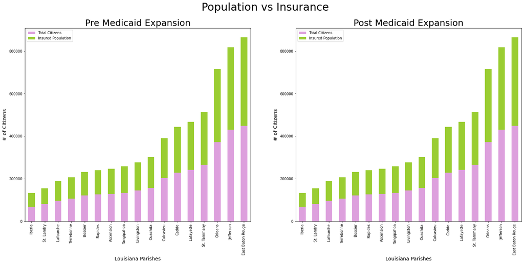

```python
fig, (ax2,ax1) = plt.subplots(1,2, figsize=(25,10))
fig.suptitle('Population vs Insurance', fontsize=30)
total_pop=pd.DataFrame(health21_total["Total Citizens"])
insured=pd.DataFrame(health21_insured["Insured Population"])
pop_insur=total_pop.join(insured,how="outer")
pop_insur.drop("US",inplace=True)
pop_insur.sort_values(by="Total Citizens",inplace=True)
pop_insur.plot.bar(stacked=True, color={"Total Citizens": "plum","Insured Population": "yellowgreen"},ax = ax1)
ax1.set_xlabel("Louisiana Parishes",fontsize=14)
ax1.set_ylabel("# of Citizens",fontsize=14)
ax1.set_title('Post Medicaid Expansion',fontsize = 25)


total_pop1=pd.DataFrame(health15_total["Total Citizens"])
insured1=pd.DataFrame(health15_insured["Insured Population"])
pop_insur1=total_pop.join(insured,how="outer")
pop_insur1.drop("US",inplace=True)
pop_insur1.sort_values(by="Total Citizens",inplace=True)
pop_insur1.plot.bar(stacked=True,color={"Total Citizens": "plum","Insured Population": "yellowgreen"}, ax = ax2)
ax2.set_xlabel("Louisiana Parishes",fontsize=14)
ax2.set_ylabel("# of Citizens",fontsize=14)
ax2.set_title('Pre Medicaid Expansion',fontsize = 25)
```

## Insurance vs Age

```python
ages21=health21_insured.sort_values(by="Insured Population",inplace=False)
ages21=ages21.filter(like="Age")
ages21=ages21.transpose()
ages21=ages21["US"]
```

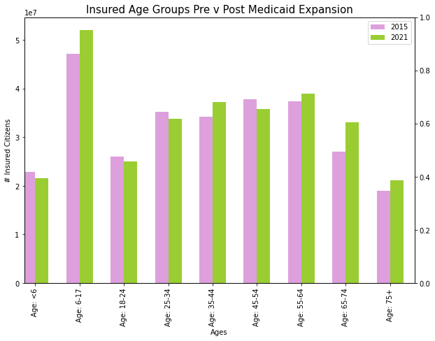

```python
ages15=health15_insured.sort_values(by="Insured Population",inplace=False)
ages15=ages15.filter(like="Age")
ages15=ages15.transpose()
ages15=ages15["US"]
fig=plt.figure()
ax=fig.add_subplot(111)
ax2=ax.twinx()
width=0.3
ages15.plot(kind='bar',color='plum',ax=ax,width=width,position=1,figsize=(10,7))
ages21.plot(kind='bar',color='yellowgreen',ax=ax,width=width,position=0,figsize=(10,7))
ax.set_ylabel("# Insured Citizens")
ax.set_xlabel("Ages")
ax.set_title("Insured Age Groups Pre v Post Medicaid Expansion",fontsize=15)
ax.legend(["2015","2021"],loc='best')
plt.show()
```

## Uninsured vs Age

```python
ages21=health21_uninsured.sort_values(by="Uninsured Population",inplace=False)
ages21=ages21.filter(like="Age")
ages21=ages21.transpose()
ages21=ages21["US"]
```

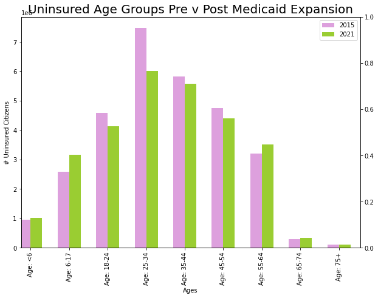

```python
ages15=health15_uninsured.sort_values(by="Uninsured Population",inplace=False)
ages15=ages15.filter(like="Age")
ages15=ages15.transpose()
ages15=ages15["US"]
fig=plt.figure()
ax=fig.add_subplot(111)
ax2=ax.twinx()
width=0.3
ages15.plot(kind='bar',color='plum',ax=ax,width=width,position=1,figsize=(10,7))
ages21.plot(kind='bar',color='yellowgreen',ax=ax,width=width,position=0)
ax.set_ylabel("# Uninsured Citizens")
ax.set_xlabel("Ages")
ax.set_title("Uninsured Age Groups Pre v Post Medicaid Expansion",fontsize=20)
ax.legend(["2015","2021"],loc='best')
plt.show()
```

Again the different is subtle, but it is noticable. The pre Medicaid expansion graph seems to peak at a higher point than the post Medicaid expansion graph. Since the graph is depicting number of uninsured citizens, it seems that Medicaid expansion could possibly have reduced the number of uninsured people, particularly in the age range of 25-34.

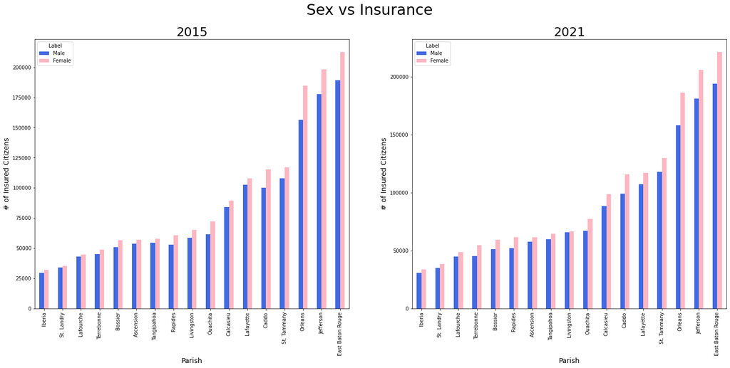

```python
fig, (ax1,ax2) = plt.subplots(1,2, figsize=(25,10))
fig.suptitle('Sex vs Insurance', fontsize=30)

sex=health21_insured.sort_values(by="Insured Population",inplace=False)
sex=sex.filter(like="ale")
sex.drop("US",inplace=True)
sex=sex.drop(sex.filter(like="reference"),axis=1)
sex=sex.drop(sex.filter(like="grad"),axis=1)
sex.plot.bar(stacked=False,color={"Male": "royalblue","Female": "lightpink"},ax=ax2)
ax2.set_xlabel("Parish",fontsize=14)
ax2.set_ylabel("# of Insured Citizens",fontsize=14)
ax2.set_title('2021',fontsize = 25)
sex=health15_insured.sort_values(by="Insured Population",inplace=False)
sex=sex.filter(like="ale")
sex.drop("US",inplace=True)
sex=sex.drop(sex.filter(like="reference"),axis=1)
sex=sex.drop(sex.filter(like="grad"),axis=1)
sex.plot.bar(stacked=False,color={"Male": "royalblue","Female": "lightpink"},ax=ax1)
ax1.set_xlabel("Parish",fontsize=14)
ax1.set_ylabel("# of Insured Citizens",fontsize=14)
ax1.set_title('2015',fontsize = 25)
#plt.show()
```

Here it doesn't look like there is much of a different between the numbers of insured by sex across the different parishes between pre Medicaid expansion and post Medicaid expansion. What is interesting, though, is that females are more insured than males in every single parish in both datasets, and there are many more insured people in East Baton Rouge than there are in Iberia (However this might be because there are just more people in East Baton Rouge).

Raw numbers are great. However, it is possible that the differences between the pre Medicaid expansion and post Medicaid expansion graphs are due to population growth or other outside factors that affect population size. To get aroud this, lets take a look at a comparison of the two datasets but this time lets use percentages instead of the numbers themselves.

```python
ages21=health21_percent_insured.sort_values(by="Insured Percent",inplace=False)
ages21=ages21.filter(like="Age")
ages21=ages21.transpose()
ages21=ages21["US"]
```

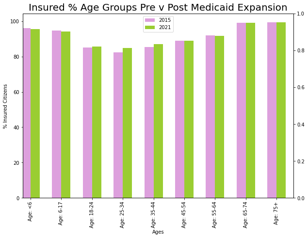

```python
ages15=health15_percent_insured.sort_values(by="Insured Percent",inplace=False)
ages15=ages15.filter(like="Age")
ages15=ages15.transpose()
ages15=ages15["US"]
fig=plt.figure()
ax=fig.add_subplot(111)
ax2=ax.twinx()
width=0.3
ages15.plot(kind='bar',color='plum',ax=ax,width=width,position=1,figsize=(10,7))
ages21.plot(kind='bar',color='yellowgreen',ax=ax,width=width,position=0,figsize=(10,7))
ax.set_ylabel("% Insured Citizens")
ax.set_xlabel("Ages")
ax.set_title("Insured % Age Groups Pre v Post Medicaid Expansion",fontsize=20)
ax.legend(["2015","2021"],loc='best')
plt.show()
```

These graphs look pretty similar. This might be because there are just subtle differences in the percentages between the two timeframes. Lets look at the uninsurance rates between pre and post Medicaid expansion to see if there are more noticable differences

```python
ages21=health21_percent_uninsured.sort_values(by="Uninsured Percent",inplace=False)
ages21=ages21.filter(like="Age")
ages21=ages21.transpose()
ages21=ages21["US"]
```

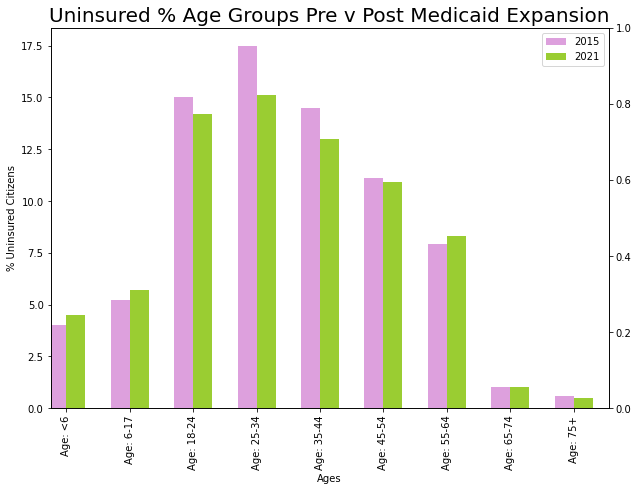

```python
ages15=health15_percent_uninsured.sort_values(by="Uninsured Percent",inplace=False)
ages15=ages15.filter(like="Age")
ages15=ages15.transpose()
ages15=ages15["US"]
fig=plt.figure()
ax=fig.add_subplot(111)
ax2=ax.twinx()
width=0.3
ages15.plot(kind='bar',color='plum',ax=ax,width=width,position=1,figsize=(10,7))
ages21.plot(kind='bar',color='yellowgreen',ax=ax,width=width,position=0,figsize=(10,7))
ax.set_ylabel("% Uninsured Citizens")
ax.set_xlabel("Ages")
ax.set_title("Uninsured % Age Groups Pre v Post Medicaid Expansion",fontsize=20)
ax.legend(["2015","2021"],loc='best')
plt.show()
```

Now the difference is much more noticable! According to these graphs, it looks like there is a difference in the percentages of people uninsured, perticularly in the 18-34 age ranges. Whats interesting is that it looks like the percentage in the 55-64, under 6, and the 6-18 age ranges actually went up after Medicaid expansion. This warrents more investigation.

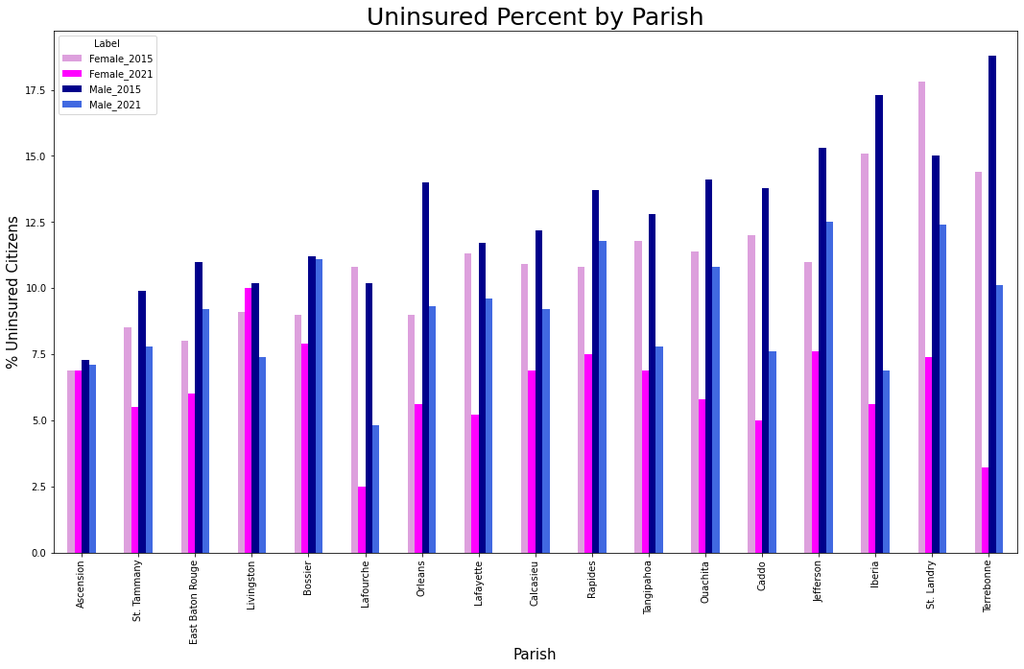

```python
import matplotlib.pyplot as plt
fig,ax = plt.subplots(1,1, figsize=(18,10))
sex=health15_percent_uninsured.sort_values(by="Uninsured Percent",inplace=False)
sex=sex.filter(like="ale")
sex.drop("US",inplace=True)
sex=sex.drop(sex.filter(like="reference"),axis=1)
sex=sex.drop(sex.filter(like="grad"),axis=1)
sex1=health21_percent_uninsured.sort_values(by="Uninsured Percent",inplace=False)
sex1.drop("US",inplace=True)
sex1 = sex1.reindex(["Ascension", "St. Tammany", "East Baton Rouge",
             "Livingston", "Bossier", "Lafourche",
             "Orleans","Lafayette","Calcasieu",
             "Rapides","Tangipahoa","Ouachita",
             "Caddo", "Jefferson", "Iberia","St. Landry", "Terrebonne"])
sex1=sex1.filter(like="ale")
sex1=sex1.drop(sex1.filter(like="reference"),axis=1)
sex1=sex1.drop(sex1.filter(like="grad"),axis=1)
sex2 = sex1.join(sex, how='outer', lsuffix='_2021', rsuffix='_2015')
sex2=sex2[["Female_2015","Female_2021","Male_2015","Male_2021"]]
sex2.plot.bar(stacked=False, color={"Male_2021": "royalblue","Female_2021": "magenta", "Male_2015": "darkblue", "Female_2015": "plum"}, ax = ax)
ax.set_ylabel("% Uninsured Citizens", fontsize = 15)
ax.set_xlabel("Parish", fontsize = 15)
ax.set_title("Uninsured Percent by Parish", fontsize = 25)
```

# 4. Which factors were affected the most by Medicaid expansion?

While it is helpful to visualize the difference between the various rates in the 2015 and the 2021 dataset, we are more interested in seeing how the adoption of Medicaid expansion changed the makeup of the insured and the uninsured populations in Louisiana.

## Feature Weights Uninsured %

Below, we are grabbing only the features shared by both datasets (some differ slightly), and putting them in order to be readable.

```python
#uninsured_features = list(set(health21_percent_uninsured.columns) & set(health15_percent_uninsured.columns))
#insured_features = list(set(health21_percent_insured.columns) & set(health15_percent_insured.columns))
uninsured_features=['Population 18 to 64 years','>= 400% of poverty threshold','< 138% of poverty threshold','Pop where poverty status determined',
                    '$100,000 and over','$75,000 to $99,999','$50,000 to $74,999', '$50,000 to $74,999','$25,000 to $49,999','$25,000 to $49,999','Under $25,000','Total household population','Did not work','Worked < full-time in past 12 months',
                     'Not in labor force','Unemployed','Employed','In labor force',"Bachelor's degree or higher","Some college or associate's degree",'High school grad','Less than high school graduate','Population 26 years and over',
                     'No disability','With a disability','Non-family household/Other','Female reference, no spouse','Male reference, no spouse','In other families','In married couple families','In family households',
                    'White alone, not Hispanic or Latino','Black or African American alone','White alone','Female','Male','Age: 75+','Age: 65-74','Age: 55-64','Age: 45-54', 'Age: 35-44',"Age: 25-34","Age: 18-24",'Uninsured Percent',"Age: <6"]
insured_features=['Population 18 to 64 years','>= 400% of poverty threshold','< 138% of poverty threshold','Pop where poverty status determined',
                    '$100,000 and over','$75,000 to $99,999','$50,000 to $74,999', '$50,000 to $74,999','$25,000 to $49,999','$25,000 to $49,999','Under $25,000','Total household population','Did not work','Worked < full-time in past 12 months',
                     'Not in labor force','Unemployed','Employed','In labor force',"Bachelor's degree or higher","Some college or associate's degree",'High school grad','Less than high school graduate','Population 26 years and over',
                     'No disability','With a disability','Non-family household/Other','Female reference, no spouse','Male reference, no spouse','In other families','In married couple families','In family households',
                    'White alone, not Hispanic or Latino','Black or African American alone','White alone','Female','Male','Age: 75+','Age: 65-74','Age: 55-64','Age: 45-54', 'Age: 35-44',"Age: 25-34","Age: 18-24",'Insured Percent',"Age: <6"]
```

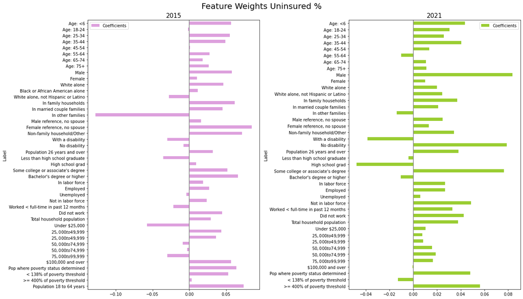

```python
fig, (ax1,ax2) = plt.subplots(1,2, figsize=(16,28),sharey=False)
fig.suptitle('Feature Weights Uninsured %', fontsize=20, y=1.02)

Y_train_15 = health15_percent_uninsured[uninsured_features]["Uninsured Percent"].copy()
X_train_15 = health15_percent_uninsured[uninsured_features].drop("Uninsured Percent", axis = 1)
X_train_15.dropna(axis = "columns",inplace = True)
reg = LinearRegression()
reg.fit(X_train_15, Y_train_15)
#Code to determine feature weights comes courtesy of the SK-Learn documentation
# https://inria.github.io/scikit-learn-mooc/python_scripts/dev_features_importance.html
coefs15_u = pd.DataFrame(
   reg.coef_,
   columns=['Coefficients'], index=X_train_15.columns
)
Y_train_21 = health21_percent_uninsured[uninsured_features]["Uninsured Percent"].copy()
X_train_21 = health21_percent_uninsured[uninsured_features].drop("Uninsured Percent", axis = 1)
X_train_21.dropna(axis = "columns",inplace = True)
reg = LinearRegression()
reg.fit(X_train_21, Y_train_21)
coefs21_u = pd.DataFrame(
   reg.coef_,
   columns=['Coefficients'], index=X_train_21.columns
)
coefs15_u.plot.barh(ax=ax1,color={"Coefficients": "plum"},figsize=(18,10))
ax1.axvline(x=0, color='.5')
ax1.set_title("2015",fontsize=15)

coefs21_u.plot.barh(ax=ax2,color={"Coefficients": "yellowgreen"}, figsize=(18,10))
ax2.axvline(x=0, color='.5')
ax2.set_title("2021",fontsize=15)
plt.tight_layout()
```

From these graphs, we can determine the most important features for predicting uninsured % in the two years. We will explore the feature importances of insured % more in our next graph below.

## Feature Weights Insured %

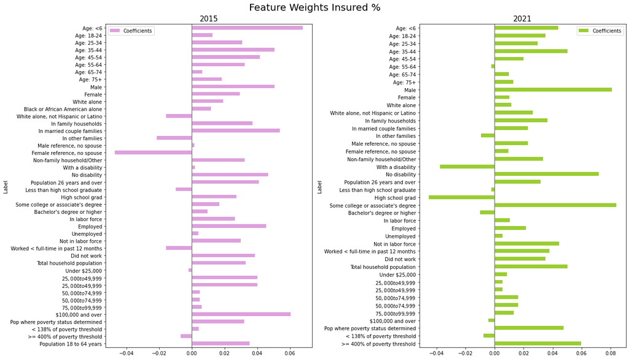

```python
fig, (ax1,ax2) = plt.subplots(1,2, figsize=(16,28),sharey=False)
fig.suptitle('Feature Weights Insured %', fontsize=20, y=1.02)

Y_train_15 = health15_percent_insured[insured_features]["Insured Percent"].copy()
X_train_15 = health15_percent_insured[insured_features].drop("Insured Percent", axis = 1)
X_train_15.dropna(axis = "columns",inplace = True)
reg = LinearRegression()
reg.fit(X_train_15, Y_train_15)

coefs15_i = pd.DataFrame(
   reg.coef_,
   columns=['Coefficients'], index=X_train_15.columns
)
Y_train_21 = health21_percent_insured[insured_features]["Insured Percent"].copy()
X_train_21 = health21_percent_insured[insured_features].drop("Insured Percent", axis = 1)
X_train_21.dropna(axis = "columns",inplace = True)
reg = LinearRegression()
reg.fit(X_train_21, Y_train_21)
coefs21_i = pd.DataFrame(
   reg.coef_,
   columns=['Coefficients'], index=X_train_21.columns
)

coefs15_i.plot.barh(ax=ax1,color={"Coefficients": "plum"},figsize=(18, 10))
ax1.axvline(x=0, color='.5')
ax1.set_title("2015",fontsize=15)

coefs21_i.plot.barh(ax=ax2, color={"Coefficients": "yellowgreen"},figsize=(18, 10))
ax2.axvline(x=0, color='.5')
ax2.set_title("2021",fontsize=15)
plt.tight_layout()
```

Here we see the feature weights for predicting insurance. On the left we have the feature importance for predicting insurance in 2015, and on the right we have the same except they're the weights for 2021. It is important to notice that the feature importance graphs for insured % look different than the graphs for feature importance for uninsured %.

## Feature Weights Insured 2021

```
array([<matplotlib.axes._subplots.AxesSubplot object at 0x7f07e8f47850>],
      dtype=object)
```

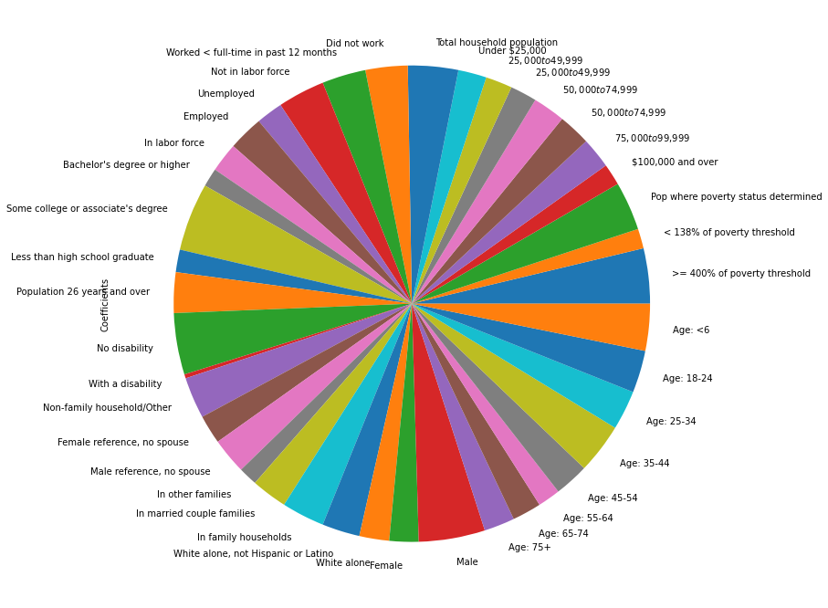

```python
#coefs21_i.set_index("Label")
coefs21_i
# copy the data
coefs21_min_max_scaled = coefs21_i.copy()
coefs21_min_max_scaled["Coefficients"] = (coefs21_min_max_scaled["Coefficients"] - coefs21_min_max_scaled["Coefficients"].min()) / (coefs21_min_max_scaled["Coefficients"].max() - coefs21_min_max_scaled["Coefficients"].min())
coefs21_min_max_scaled.plot.pie(subplots=True,figsize=(12,12),legend=False)
```

This might bring up a question.. does having a disability in Louisiana mean you are less likely to be insured??

```python
coefs15_u.reset_index(inplace=True)
coefs15_uninsured=coefs15_u.copy()
coefs15_u["Coefficients"]=coefs15_u["Coefficients"].abs()
(coefs15_u["Coefficients"]>0.065).value_counts()
new_coefs15_u=coefs15_u[coefs15_u["Coefficients"]>0.065]
new_coefs15_u.dropna(inplace=True)
new_coefs15_u.sort_values(by="Coefficients",ascending=True,inplace=True)
x1=new_coefs15_u["Label"]
y1=new_coefs15_u["Coefficients"]
```

```python
coefs21_u.reset_index(inplace=True)
coefs21_uninsured=coefs21_u.copy()
coefs21_u["Coefficients"]=coefs21_u["Coefficients"].abs()
(coefs21_u["Coefficients"]>0.048).value_counts()
new_coefs21_u=coefs21_u[coefs21_u["Coefficients"]>0.048]
new_coefs21_u.dropna(inplace=True)
new_coefs21_u.sort_values(by="Coefficients",ascending=True,inplace=True)
x2=new_coefs21_u["Label"]
y2=new_coefs21_u["Coefficients"]
```

```python
coefs15_uninsured.drop(index=0,inplace=True)
coefs15_uninsured.drop(index=31,inplace=True)
coefs15_uninsured.dropna()
coefs15_uninsured.reset_index(inplace=True)
```

```python
coefs15_i.reset_index(inplace=True)
coefs15_insured=coefs15_i.copy()
coefs15_i["Coefficients"]=coefs15_i["Coefficients"].abs()
(coefs15_i["Coefficients"]>0.05).value_counts()
new_coefs15_i=coefs15_i[coefs15_i["Coefficients"]>0.05]
new_coefs15_i.dropna(inplace=True)
new_coefs15_i.sort_values(by="Coefficients",ascending=True,inplace=True)
x3=new_coefs15_i["Label"]
y3=new_coefs15_i["Coefficients"]
```

```python
coefs21_i.reset_index(inplace=True)
coefs21_insured=coefs21_i.copy()
coefs21_i["Coefficients"]=coefs21_i["Coefficients"].abs()
(coefs21_i["Coefficients"]>0.0503).value_counts()
new_coefs21_i=coefs21_i[coefs21_i["Coefficients"]>0.0503]
new_coefs21_i.dropna(inplace=True)
new_coefs21_i.sort_values(by="Coefficients",ascending=True,inplace=True)
x4=new_coefs21_i["Label"]
y4=new_coefs21_i["Coefficients"]
```

```python
coefs15_insured.drop(index=0,inplace=True)
coefs15_insured.drop(index=31,inplace=True)
coefs15_insured.dropna()
coefs15_insured.reset_index(inplace=True)
```

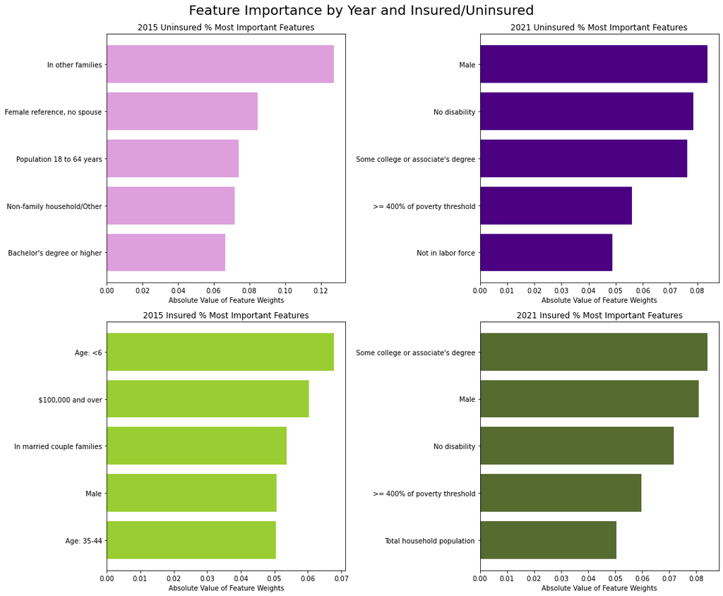

```python
fig, ((ax1, ax2), (ax3, ax4)) = plt.subplots(2, 2,figsize=(15,12))
fig.suptitle('Feature Importance by Year and Insured/Uninsured', fontsize=20, y=1.02)

ax1.barh(x1, y1,color={'plum'})
ax1.set_title("2015 Uninsured % Most Important Features")
ax1.set_xlabel("Absolute Value of Feature Weights")

ax2.barh(x2, y2,color={'indigo'})
ax2.set_title("2021 Uninsured % Most Important Features")
ax2.set_xlabel("Absolute Value of Feature Weights")
plt.tight_layout()

ax3.barh(x3, y3,color={'yellowgreen'})
ax3.set_title("2015 Insured % Most Important Features")
ax3.set_xlabel("Absolute Value of Feature Weights")

ax4.barh(x4, y4,color={'darkolivegreen'})
ax4.set_title("2021 Insured % Most Important Features")
ax4.set_xlabel("Absolute Value of Feature Weights")
plt.tight_layout()
```

As you can see above, the factors differ in which has the highest feature weights depending on year and insured/uninsured %. Our next goal is to take these 5 most important features and use them to predict the 2021 data on the 2015 data. We will explore this in the last section of our analysis.

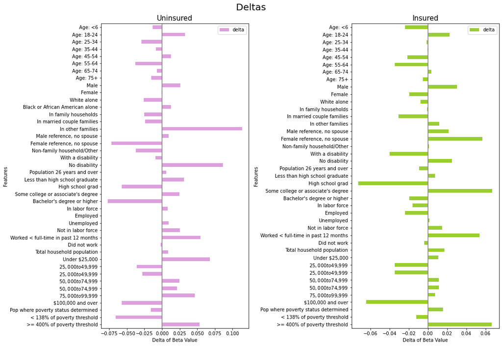

```python
fig, (ax1,ax2) = plt.subplots(1,2, figsize=(14,14),sharey=False)
fig.suptitle('Deltas', fontsize=20, y=1.02)

coefs_joined_u=coefs15_uninsured.join(other=coefs21_uninsured,how="inner",lsuffix="_2015",rsuffix="_2021")
coefs_joined_u["delta"]=coefs_joined_u["Coefficients_2021"]-coefs_joined_u["Coefficients_2015"]
coefs_joined_u.rename(columns={"Label_2015":"Features"},inplace=True)
coefs_joined_u.set_index("Features",inplace=True)
coefs_joined_u.drop(columns={"Label_2021","Coefficients_2021","Coefficients_2015","index"},inplace=True)

coefs_joined_i=coefs15_insured.join(other=coefs21_insured,how="inner",lsuffix="_2015",rsuffix="_2021")
coefs_joined_i.drop(index=30,inplace=True)
coefs_joined_i["delta"]=coefs_joined_i["Coefficients_2021"]-coefs_joined_i["Coefficients_2015"]
coefs_joined_i.rename(columns={"Label_2015":"Features"},inplace=True)
coefs_joined_i.set_index("Features",inplace=True)
coefs_joined_i.drop(columns={"Label_2021","Coefficients_2021","Coefficients_2015","index"},inplace=True)

coefs_joined_u.plot.barh(ax=ax1,color={"delta": "plum"},figsize=(15, 10))
ax1.axvline(x=0, color='.5')
ax1.set_title("Uninsured",fontsize=15)
ax1.set_xlabel("Delta of Beta Value")

coefs_joined_i.plot.barh(ax=ax2,color={"delta": "yellowgreen"},figsize=(15, 10))
ax2.axvline(x=0, color='.5')
ax2.set_title("Insured",fontsize=15)
ax2.set_xlabel("Delta of Beta Value")
plt.tight_layout()
```

Here we have the difference in feature weights between 2021 and 2015 for both insured % and uninsured %. One of the most important points on this graph is the delta for "<138 % of poverty threshold" on the uninsured deltas graph.

As is clear, the value for this delta is very negative which means that from 2015 to 2021 being below 138% of the povery threshold became negatively associated with being uninsured.

In plain english, this means that you are LESS likely to be uninsured in 2021 than you were in 2015 if you are below 138% of the poverty threshold. This is important to realize because one of the main tennants of Medicaid expansion is that if you were below 138% of the poverty threshold, you became eligable for Medicaid. This graph is highlighting one of the main effects of Medicaid expansion.

# Did Medicaid change the course of Insurance rates in Louisiana?

To answer this key question we can use a linear regression.

Here is how the process will work:

1. We will fit our model to the 2015 insured dataset, using the most important features that were determined in the Feature importance graph above
2. We will then predict the 2021 insurance rates, using the same features that we used to fid our model
3. Then, we will compare the predicted 2021 insurance rate value with the actual 2021 insurance rate value

We chose 5 factors to explore this linear regression. We chose these for specific reasons described below, but overall we were looking for factors that would impact a person's ability or choice to be insured by Medicaid expansion.

**Male** - came up in 3 of the feature weights as one of the most important factors.

**<138% of poverty threshold** - This is the group that should be directly effected by Medicaid Expansion. They are now eligible for Medicaid so we expect to see an increase in their insurance rates.

**No disability** - Shown in 2 of the feature weights, emphasizes the importance of peole who don't suffer from any disabilities, which may include a majority of healthy adults living in Louisiana. These people have no incentive to be insured because of a specific disability, so they will be effected heavily by Medicaid expansion.

**In married couple families** - The so-called "normal" households, this also came up in one of our feature weight importance graphs.

**Age: 35-44**: This is an age group highly effected by Medicaid. They fit the criteria for expansion and din't qualify before. Also seen in a feature importance graph.

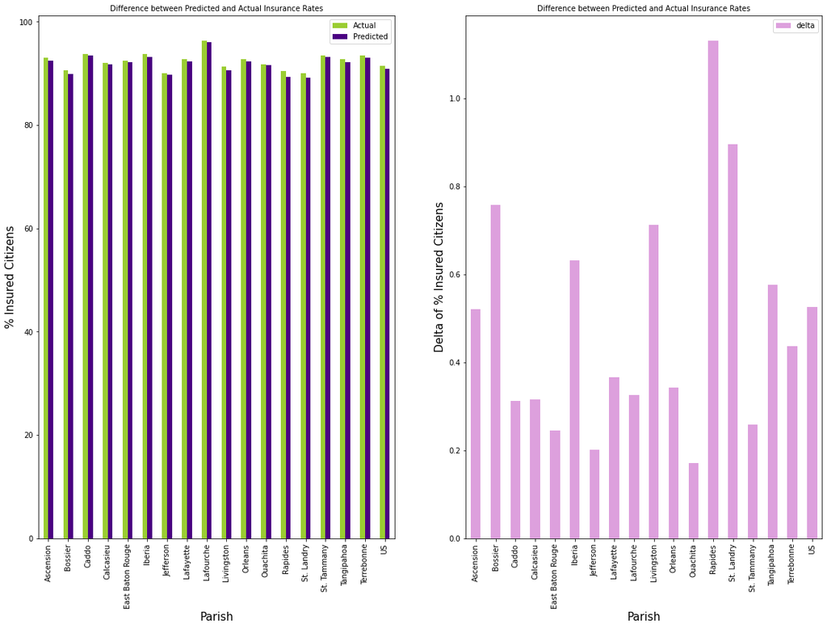

```python
fig, (ax1,ax2) = plt.subplots(1,2, figsize=(19,13),sharey=False)
X_train = health15_percent_insured[["Male","< 138% of poverty threshold","No disability","In married couple families","Age: 35-44"]]
Y_train = health15_percent_insured["Insured Percent"]
X_test = health21_percent_insured[["Male","< 138% of poverty threshold","No disability","In married couple families","Age: 35-44"]]
Y_test = health21_percent_insured["Insured Percent"]

regressor = LinearRegression()
regressor.fit(X_train, Y_train)
y_pred = regressor.predict(X_test)
Pred_v_Actual = pd.DataFrame({'Actual': Y_test, 'Predicted': y_pred.flatten()})
Pred_v_Actual["delta"]=Pred_v_Actual["Actual"]-Pred_v_Actual["Predicted"]
Pred_v_Actual_nodelt=Pred_v_Actual.drop(columns={"delta"})
Pred_v_Actual_nodelt.plot.bar(ax=ax1,color={"Actual":"yellowgreen","Predicted":"indigo"})
ax1.set_title("Difference between Predicted and Actual Insurance Rates", fontsize = 10)
ax1.set_ylabel("% Insured Citizens", fontsize = 15)
ax1.set_xlabel("Parish", fontsize = 15)

Pred_v_Actual_=Pred_v_Actual.drop(columns={"Predicted","Actual"})
Pred_v_Actual_.plot.bar(ax=ax2,color="plum")
ax2.set_title("Difference between Predicted and Actual Insurance Rates", fontsize = 10)
ax2.set_ylabel("Delta of % Insured Citizens", fontsize = 15)
ax2.set_xlabel("Parish", fontsize = 15)
```

These two models show the differences between our prediction for insurance rates of 2021 with the linear regression model and the acutal insurance rates. The left graph shows that all Predicted values were equal to or lower than the Actual values. This shows that actual insurance rates were higher than they wouldn've been without Medicaid!! A great sign!!

The right graph shows an enlarged version of these differences by observing the delta (or difference) between the predicted and observed values. This graph shows us more clearly the differences between parishes, and some parishes such as Rapides and St. Landry were able to highly improve insurance rates thanks to Medicaid. Other parishes such as Ouachita and Jefferson had less of a change, even though we saw a net improvement across all parishes.

# Conclusion

Our analysis has been a learning process with insurance and Medicaid expansion. Louisiana is an interesting test case to evaluate since the populations vary here between rural and suburban, and there are huge differences in beliefs such as vaccination, abortion, and more medically-related political controversies. Our analysis has shown that insurance correlates much less with some factors we had expected, yet much more with others. We discovered how large a role gender plays in insurance rates, yet how race plays a smaller role.

As is the case with any predictive model, ours is not perfect. A key assumption that we made about the rates of insurance and uninsurance is that they are in a linear relationship with the features we selected. Because of this assumption, we chose to use a linear regression for our predictions and we got some associations that look strange at first glance.

It is entirely possible that the associations between insurance rates and the features of the dataset are linear, but its more likely that there are non-linear relationships in these data. Furthermore, its entirely possible that there are non-linear relationships between the features themselves that affect rates of insurance.

That is not to say that our model is not capable of reflecting some part of the real world. However, it is important to keep in mind that just because we used "machine learning" doesn't mean that we have unlocked all the secrets of insurance rates in Louisiana. With more resources, it would be worth examining each parish in our dataset individually and seeing what we find. Additionally, it would be worthwhile to explore the use of non-linear models that might more "accurately" capture the relationships of the features.

In conclusion, we were able to examine some interesting aspects of many population features and their relationship to rates of insurance. This is by no means an exhaustive analysis, but it is a good first look at this interesting problem.

```python
%%shell
jupyter nbconvert --to html /content/drive/MyDrive/Colab_Notebooks/Data_Science_Project.ipynb
```

```
[NbConvertApp] Converting notebook /content/drive/MyDrive/Colab_Notebooks/Data_Science_Project.ipynb to html
[NbConvertApp] Writing 1855087 bytes to /content/drive/MyDrive/Colab_Notebooks/Data_Science_Project.html
```